# Cleveland Baseball Game Duration

Data Exploration

Michael Foley

2023-07-21

Average pace of play slowed from a little over two hours per nine-innings in the 1940s to a brutal 3:16 in 2021. This project investigates reasons for the increase, and measures the effect of recent efforts to quicken the pace of play. This section is an overview of these data sources and what they offer for analysis.

- Cleveland game and season summaries scraped from [Baseball-Reference](https://www.baseball-reference.com/teams/CLE/2023.shtml) web pages.
- Team season summaries and MLB pace of play from MLB’s publicly accessible (but apparently undocumented) API.
- [Retrosheet’s](https://www.retrosheet.org/) game and event files.

In addition to insights that should guide further research, this script performs minor data engineering tasks to prep the data sets for model fitting. The output is four time-series tsibbles, `bref_cle_season_ts`, `mlb_season_ts`, `retro_season_g_ts`, and `retro_season_e_ts` saved in the project data directory.

# Raw Data from Step 01

Prior to running this report, I ran

- 01_get_bref_cle.R to scrape game summaries from Baseball-Reference.com. This source updates daily, so re-run to refresh YTD.
- 01_get_mlb.R to pull from the MLB API. Also updates daily.
- [01-get-retro_game.R](https://github.com/mpfoley73/mlb-games/blob/main/src/01_get_retro_game.R) to load game summaries downloaded from Retrosheet. Updates once per season, so no need to re-run.
- [01-get-retro-even.R](https://github.com/mpfoley73/mlb-games/blob/main/src/01_get_retro_event.R) to download and process with Chadwick game-event files from Retrosheet. Updates once per season.

```r
# 01_get_bref_cle.R. Re-run source to refresh 2023.
if(refresh_2023) source("01_get_bref_cle.R")
bref_cle_games <- readRDS(file.path(proj_dir, "data/bref_cle_games.rds"))
bref_cle_batting <- readRDS(file.path(proj_dir, "data/bref_cle_batting.rds"))
bref_cle_pitching <- readRDS(file.path(proj_dir, "data/bref_cle_pitching.rds"))

# 01_get_mlb.R. Re-run source to refresh 2023.
last_run <- ymd("2023-07-19")
if(refresh_2023) source("01_get_mlb.R")
mlb_pace <- readRDS(file.path(proj_dir, "data/mlb_pace.rds"))
mlb_batting <- readRDS(file.path(proj_dir, "data/mlb_batting.rds"))
mlb_pitching <- readRDS(file.path(proj_dir, "data/mlb_pitching.rds"))

# 01_get_retro_game.
retro_games <- readRDS(file.path(proj_dir, "data/retro_game.rds"))

# 01_get_retro_event.
retro_events <- readRDS(file.path(proj_dir, "data/retro_event.rds"))
```

All four sources provide game duration. Baseball-reference was the most difficult to assemble, so I only collected Cleveland games. It does not have any data that isn’t available in one or more of the other data sources. The MLB-API is nice because it covers the current season, and includes pitch counts. The Retrosheet Games data was simple to pull, but has limited coverage. The gold standard is the Retrosheet Events data. Difficult to assemble, but it has everything, including mid-inning pitcher substitutions. The only problem is coverage - it only goes back to 1914. I may ultimately use multiple sources in the final analysis.

[output not shown]

**Table 1**. Coverage for data sources used in this analysis. Baseball-Reference and MLB API last collected on Jul 09, 2023.

## Baseball-Reference

R script **01_get_bref_cle.R** scraped 123 seasons of Cleveland baseball game summaries, including the 2023 season through Jul 09, from [Baseball-Reference](https://www.baseball-reference.com/teams/CLE/2023.shtml). Baseball-Reference has one web page for each team and season. The pages include a table of game summaries. The R script loops through each season and scrapes the table. I ran it through all seasons through 2022, then set it to just refresh the 2023 season. *Note to self: run the script periodically to refresh this analysis by setting* `refresh_2023 = TRUE`. Data set `bref_cle_games` is a 19,079 x 24 data frame with one row per each of the 19,079 games from 1901 - Jul 09, 2023. The Baseball-Reference pages also have player summaries which the R script scrapes as well. `bref_cle_batting` (4,817 x 28) has season statistics for 1,971 Cleveland batters. `bref_cle_pitching` (2,152 x 34) has stats for 939 pitchers.

### bref_cle_games

Data summary

| Name | bref_cle_games |
| --- | --- |
| Number of rows | 19079 |
| Number of columns | 24 |
| _______________________ |  |
| Column type frequency: |  |
| character | 6 |
| Date | 1 |
| factor | 4 |
| numeric | 12 |
| Timespan | 1 |
| ________________________ |  |
| Group variables | None |

**Variable type: character**

| skim_variable | n_missing | complete_rate | min | max | empty | n_unique | whitespace |
| --- | --- | --- | --- | --- | --- | --- | --- |
| opponent | 0 | 1 | 3 | 3 | 0 | 42 | 0 |
| old_record | 0 | 1 | 3 | 6 | 0 | 4162 | 0 |
| new_record | 0 | 1 | 3 | 6 | 0 | 4203 | 0 |
| winning_pitcher | 0 | 1 | 0 | 13 | 92 | 2076 | 0 |
| losing_pitcher | 0 | 1 | 0 | 13 | 92 | 2344 | 0 |
| save | 0 | 1 | 0 | 13 | 13045 | 1056 | 0 |

**Variable type: Date**

| skim_variable | n_missing | complete_rate | min | max | median | n_unique |
| --- | --- | --- | --- | --- | --- | --- |
| game_date | 0 | 1 | 1901-04-24 | 2023-07-09 | 1963-05-11 | 17266 |

**Variable type: factor**

| skim_variable | n_missing | complete_rate | ordered | n_unique | top_counts |
| --- | --- | --- | --- | --- | --- |
| outcome | 0 | 1 | FALSE | 3 | W: 9729, L: 9260, T: 90 |
| home_ind | 0 | 1 | FALSE | 2 | Hom: 9552, Awa: 9527 |
| day_ind | 0 | 1 | FALSE | 2 | Day: 11739, Nig: 7340 |
| doubleheader_game | 0 | 1 | FALSE | 3 | 0: 15453, 1: 1813, 2: 1813 |

**Variable type: numeric**

| skim_variable | n_missing | complete_rate | mean | sd | p0 | p25 | p50 | p75 | p100 | hist |
| --- | --- | --- | --- | --- | --- | --- | --- | --- | --- | --- |
| season | 0 | 1.00 | 1962.21 | 35.19 | 1901 | 1932.0 | 1963.0 | 1993.00 | 2023 | ▇▇▇▇▇ |
| game_no | 0 | 1.00 | 78.65 | 45.52 | 1 | 39.0 | 78.0 | 118.00 | 164 | ▇▇▇▇▆ |
| runs_scored | 0 | 1.00 | 4.52 | 3.22 | 0 | 2.0 | 4.0 | 6.00 | 27 | ▇▃▁▁▁ |
| runs_allowed | 0 | 1.00 | 4.41 | 3.15 | 0 | 2.0 | 4.0 | 6.00 | 24 | ▇▅▁▁▁ |
| innings | 0 | 1.00 | 9.18 | 0.90 | 5 | 9.0 | 9.0 | 9.00 | 22 | ▁▇▁▁▁ |
| attendance | 2719 | 0.86 | 17359.52 | 13544.30 | 200 | 6219.5 | 13757.5 | 25376.25 | 84587 | ▇▃▂▁▁ |
| old_rank | 0 | 1.00 | 3.68 | 1.97 | 1 | 2.0 | 4.0 | 5.00 | 10 | ▇▇▆▂▁ |
| old_games_back | 0 | 1.00 | 8.01 | 9.38 | -29 | 1.5 | 6.5 | 13.50 | 49 | ▁▃▇▂▁ |
| old_streak | 0 | 1.00 | 3.21 | 1.30 | -11 | 3.0 | 3.0 | 4.00 | 9 | ▁▁▁▇▁ |
| new_rank | 0 | 1.00 | 3.70 | 1.96 | 1 | 2.0 | 4.0 | 5.00 | 10 | ▇▇▆▂▁ |
| new_games_back | 0 | 1.00 | 8.10 | 9.44 | -30 | 1.5 | 6.5 | 13.50 | 49 | ▁▃▇▂▁ |
| new_streak | 0 | 1.00 | 3.23 | 1.27 | -11 | 3.0 | 3.0 | 4.00 | 9 | ▁▁▁▇▁ |

**Variable type: Timespan**

| skim_variable | n_missing | complete_rate | min | max | median | n_unique |
| --- | --- | --- | --- | --- | --- | --- |
| dur | 481 | 0.97 | 2100 | 23760 | 8940 | 263 |

### bref_cle_batting

Data summary

| Name | bref_cle_batting |
| --- | --- |
| Number of rows | 4817 |
| Number of columns | 28 |
| _______________________ |  |
| Column type frequency: |  |
| character | 2 |
| numeric | 26 |
| ________________________ |  |
| Group variables | None |

**Variable type: character**

| skim_variable | n_missing | complete_rate | min | max | empty | n_unique | whitespace |
| --- | --- | --- | --- | --- | --- | --- | --- |
| Pos | 0 | 1 | 0 | 2 | 56 | 16 | 0 |
| Name | 0 | 1 | 7 | 30 | 0 | 1971 | 0 |

**Variable type: numeric**

| skim_variable | n_missing | complete_rate | mean | sd | p0 | p25 | p50 | p75 | p100 | hist |
| --- | --- | --- | --- | --- | --- | --- | --- | --- | --- | --- |
| season | 0 | 1.00 | 1966.26 | 35.73 | 1901 | 1936.00 | 1968.00 | 1998.00 | 2023 | ▆▆▆▆▇ |
| Age | 0 | 1.00 | 27.55 | 4.22 | 17 | 25.00 | 27.00 | 30.00 | 48 | ▂▇▃▁▁ |
| G | 0 | 1.00 | 44.05 | 49.68 | 0 | 3.00 | 24.00 | 75.00 | 163 | ▇▂▁▁▂ |
| PA | 0 | 1.00 | 152.06 | 207.99 | 0 | 2.00 | 44.00 | 241.00 | 751 | ▇▁▁▁▁ |
| AB | 23 | 1.00 | 135.70 | 184.14 | 0 | 2.00 | 40.00 | 219.00 | 663 | ▇▁▁▁▁ |
| R | 23 | 1.00 | 18.01 | 27.83 | 0 | 0.00 | 3.00 | 26.00 | 140 | ▇▁▁▁▁ |
| H | 23 | 1.00 | 35.97 | 52.76 | 0 | 0.00 | 7.50 | 54.00 | 233 | ▇▁▁▁▁ |
| 2B | 23 | 1.00 | 6.41 | 10.21 | 0 | 0.00 | 1.00 | 9.00 | 64 | ▇▁▁▁▁ |
| 3B | 23 | 1.00 | 1.14 | 2.46 | 0 | 0.00 | 0.00 | 1.00 | 26 | ▇▁▁▁▁ |
| HR | 23 | 1.00 | 2.84 | 6.37 | 0 | 0.00 | 0.00 | 2.00 | 52 | ▇▁▁▁▁ |
| RBI | 23 | 1.00 | 16.64 | 26.46 | 0 | 0.00 | 3.00 | 23.00 | 165 | ▇▁▁▁▁ |
| SB | 23 | 1.00 | 2.43 | 6.12 | 0 | 0.00 | 0.00 | 2.00 | 75 | ▇▁▁▁▁ |
| CS | 544 | 0.89 | 1.26 | 2.71 | 0 | 0.00 | 0.00 | 1.00 | 27 | ▇▁▁▁▁ |
| BB | 23 | 1.00 | 12.89 | 20.97 | 0 | 0.00 | 2.00 | 17.00 | 127 | ▇▁▁▁▁ |
| SO | 23 | 1.00 | 19.30 | 27.43 | 0 | 0.00 | 7.00 | 27.00 | 194 | ▇▁▁▁▁ |
| BA | 1053 | 0.78 | 0.22 | 0.12 | 0 | 0.16 | 0.23 | 0.28 | 1 | ▅▇▁▁▁ |
| OBP | 1046 | 0.78 | 0.28 | 0.14 | 0 | 0.22 | 0.30 | 0.35 | 1 | ▂▇▁▁▁ |
| SLG | 1053 | 0.78 | 0.31 | 0.19 | 0 | 0.20 | 0.32 | 0.41 | 4 | ▇▁▁▁▁ |
| OPS | 1053 | 0.78 | 0.58 | 0.31 | 0 | 0.43 | 0.63 | 0.75 | 5 | ▇▁▁▁▁ |
| OPS+ | 1053 | 0.78 | 59.83 | 82.41 | -100 | 21.00 | 73.00 | 105.00 | 1201 | ▇▁▁▁▁ |
| TB | 23 | 1.00 | 53.18 | 80.60 | 0 | 0.00 | 10.00 | 79.00 | 405 | ▇▁▁▁▁ |
| GDP | 1317 | 0.73 | 2.96 | 4.71 | 0 | 0.00 | 0.00 | 4.00 | 28 | ▇▂▁▁▁ |
| HBP | 23 | 1.00 | 0.98 | 2.11 | 0 | 0.00 | 0.00 | 1.00 | 25 | ▇▁▁▁▁ |
| SH | 23 | 1.00 | 2.38 | 4.93 | 0 | 0.00 | 0.00 | 3.00 | 67 | ▇▁▁▁▁ |
| SF | 1854 | 0.62 | 1.11 | 2.03 | 0 | 0.00 | 0.00 | 1.00 | 16 | ▇▁▁▁▁ |
| IBB | 822 | 0.83 | 0.89 | 2.19 | 0 | 0.00 | 0.00 | 1.00 | 23 | ▇▁▁▁▁ |

### bref_cle_pitching

Data summary

| Name | bref_cle_pitching |
| --- | --- |
| Number of rows | 2152 |
| Number of columns | 34 |
| _______________________ |  |
| Column type frequency: |  |
| character | 2 |
| numeric | 32 |
| ________________________ |  |
| Group variables | None |

**Variable type: character**

| skim_variable | n_missing | complete_rate | min | max | empty | n_unique | whitespace |
| --- | --- | --- | --- | --- | --- | --- | --- |
| Pos | 0 | 1 | 0 | 2 | 989 | 4 | 0 |
| Name | 0 | 1 | 7 | 30 | 0 | 939 | 0 |

**Variable type: numeric**

| skim_variable | n_missing | complete_rate | mean | sd | p0 | p25 | p50 | p75 | p100 | hist |
| --- | --- | --- | --- | --- | --- | --- | --- | --- | --- | --- |
| season | 0 | 1.00 | 1970.06 | 35.93 | 1901.00 | 1940.00 | 1974.00 | 2002.00 | 2023.00 | ▅▅▅▆▇ |
| Age | 0 | 1.00 | 27.51 | 4.23 | 17.00 | 25.00 | 27.00 | 30.00 | 48.00 | ▂▇▃▁▁ |
| W | 0 | 1.00 | 4.52 | 5.60 | 0.00 | 0.00 | 2.00 | 7.00 | 31.00 | ▇▂▁▁▁ |
| L | 0 | 1.00 | 4.30 | 4.44 | 0.00 | 1.00 | 3.00 | 7.00 | 22.00 | ▇▂▂▁▁ |
| W-L% | 373 | 0.83 | 0.46 | 0.26 | 0.00 | 0.33 | 0.50 | 0.61 | 1.00 | ▃▅▇▃▂ |
| ERA | 8 | 1.00 | 4.92 | 4.39 | 0.00 | 3.10 | 4.16 | 5.40 | 81.00 | ▇▁▁▁▁ |
| G | 0 | 1.00 | 22.42 | 17.49 | 0.00 | 7.00 | 20.50 | 34.00 | 81.00 | ▇▅▃▁▁ |
| GS | 0 | 1.00 | 8.87 | 11.47 | 0.00 | 0.00 | 3.00 | 16.00 | 44.00 | ▇▂▁▂▁ |
| GF | 0 | 1.00 | 6.04 | 9.10 | 0.00 | 1.00 | 3.00 | 8.00 | 67.00 | ▇▁▁▁▁ |
| CG | 0 | 1.00 | 2.83 | 5.81 | 0.00 | 0.00 | 0.00 | 2.00 | 36.00 | ▇▁▁▁▁ |
| SHO | 0 | 1.00 | 0.46 | 1.14 | 0.00 | 0.00 | 0.00 | 0.00 | 10.00 | ▇▁▁▁▁ |
| SV | 0 | 1.00 | 1.39 | 4.45 | 0.00 | 0.00 | 0.00 | 1.00 | 46.00 | ▇▁▁▁▁ |
| IP | 0 | 1.00 | 78.99 | 79.18 | 0.00 | 15.07 | 52.15 | 122.40 | 371.10 | ▇▂▂▁▁ |
| H | 0 | 1.00 | 78.74 | 76.43 | 0.00 | 17.00 | 53.00 | 124.50 | 378.00 | ▇▂▂▁▁ |
| R | 0 | 1.00 | 39.09 | 36.05 | 0.00 | 10.00 | 26.00 | 61.25 | 167.00 | ▇▃▂▁▁ |
| ER | 0 | 1.00 | 33.75 | 31.06 | 0.00 | 8.00 | 23.00 | 53.00 | 150.00 | ▇▃▂▁▁ |
| HR | 0 | 1.00 | 5.99 | 6.80 | 0.00 | 1.00 | 3.00 | 9.00 | 37.00 | ▇▂▁▁▁ |
| BB | 0 | 1.00 | 29.39 | 28.59 | 0.00 | 7.00 | 20.50 | 44.00 | 208.00 | ▇▂▁▁▁ |
| IBB | 377 | 0.82 | 2.21 | 2.65 | 0.00 | 0.00 | 1.00 | 3.00 | 20.00 | ▇▁▁▁▁ |
| SO | 0 | 1.00 | 45.01 | 49.43 | 0.00 | 8.00 | 29.00 | 64.00 | 348.00 | ▇▂▁▁▁ |
| HBP | 0 | 1.00 | 2.14 | 2.65 | 0.00 | 0.00 | 1.00 | 3.00 | 24.00 | ▇▁▁▁▁ |
| BK | 0 | 1.00 | 0.25 | 0.64 | 0.00 | 0.00 | 0.00 | 0.00 | 8.00 | ▇▁▁▁▁ |
| WP | 0 | 1.00 | 2.21 | 2.72 | 0.00 | 0.00 | 1.00 | 3.00 | 18.00 | ▇▂▁▁▁ |
| BF | 0 | 1.00 | 338.26 | 330.50 | 0.00 | 69.00 | 230.50 | 529.00 | 1548.00 | ▇▂▂▁▁ |
| ERA+ | 74 | 0.97 | 104.14 | 55.85 | 3.00 | 74.00 | 95.00 | 122.00 | 854.00 | ▇▁▁▁▁ |
| FIP | 8 | 1.00 | 4.41 | 2.41 | -2.89 | 3.36 | 4.08 | 4.85 | 60.13 | ▇▁▁▁▁ |
| WHIP | 8 | 1.00 | 1.56 | 0.70 | 0.00 | 1.26 | 1.43 | 1.67 | 15.00 | ▇▁▁▁▁ |
| H9 | 8 | 1.00 | 9.89 | 4.32 | 0.00 | 8.00 | 9.20 | 10.80 | 54.00 | ▇▂▁▁▁ |
| HR9 | 8 | 1.00 | 0.87 | 1.24 | 0.00 | 0.20 | 0.70 | 1.10 | 27.00 | ▇▁▁▁▁ |
| BB9 | 8 | 1.00 | 4.20 | 3.32 | 0.00 | 2.70 | 3.60 | 4.80 | 81.00 | ▇▁▁▁▁ |
| SO9 | 8 | 1.00 | 5.32 | 3.00 | 0.00 | 3.30 | 4.80 | 7.00 | 27.00 | ▇▅▁▁▁ |
| SO_per_BB | 71 | 0.97 | 1.61 | 1.29 | 0.00 | 0.82 | 1.33 | 2.00 | 23.00 | ▇▁▁▁▁ |

## MLB API

The MLB API is publicly accessible. R package [baseballr](https://github.com/BillPetti/baseballr/) is an excellent tool for pulling this data. However, the MLB API seems to have no public documentation, and the functionality changes. I had trouble getting **baseballr** to work, probably because the API is a moving target. I was able to copy/paste the important code into my own script, **01_get_mlb.R**, and get the data I needed. One particularly useful module in the API is **gamePace**, an incredible set of metrics related to game pace. You can get data at the individual game level, or summarized by team. I originally wanted to focus on just Cleveland, but the team summaries only show the team’s *home* games. So if you want season summaries for one team, you need game summaries for *all* teams, then untangle the home and visting data. This was just too much effort, so I shifted my focus to MLB as a whole. As with **01_get_bref_cle.R**, I used my MLB R script download all seasons through 2022, then set it to just refresh 2023. *Run this script too when you refresh 2023!* Data set `mlb_pace` is a 123 x 11 data frame with one row per each season, 1901-1923. Data sets `mlb_batting` (2,662 x 24) and `mlb_pitching` (2,662 x 29) have one row per team and season. I summarized the player summaries to augment the `mlb_pace` data with offense and defense statistics.

### mlb_pace

Data summary

| Name | mlb_pace |
| --- | --- |
| Number of rows | 123 |
| Number of columns | 11 |
| _______________________ |  |
| Column type frequency: |  |
| numeric | 9 |
| Timespan | 2 |
| ________________________ |  |
| Group variables | None |

**Variable type: numeric**

| skim_variable | n_missing | complete_rate | mean | sd | p0 | p25 | p50 | p75 | p100 | hist |
| --- | --- | --- | --- | --- | --- | --- | --- | --- | --- | --- |
| season | 0 | 1.0 | 1962.00 | 35.65 | 1901 | 1931.5 | 1962 | 1992.50 | 2023.0 | ▇▇▇▇▇ |
| G | 0 | 1.0 | 1672.55 | 505.87 | 898 | 1236.0 | 1394 | 2105.50 | 2432.0 | ▁▇▁▃▃ |
| extra_I_G | 0 | 1.0 | 154.84 | 44.51 | 79 | 115.0 | 143 | 195.50 | 243.0 | ▆▇▂▇▃ |
| I | 0 | 1.0 | 14983.28 | 4542.44 | 7759 | 11039.0 | 12588 | 18936.75 | 21899.5 | ▁▇▁▃▃ |
| H | 0 | 1.0 | 29661.65 | 8932.43 | 14439 | 21989.5 | 24916 | 37773.00 | 45327.0 | ▂▇▂▃▅ |
| R | 0 | 1.0 | 14757.19 | 4885.18 | 7385 | 11009.5 | 12747 | 18629.00 | 24971.0 | ▆▇▃▃▃ |
| PA | 0 | 1.0 | 127314.35 | 39589.23 | 66506 | 95146.0 | 105892 | 160981.00 | 190261.0 | ▂▇▂▃▅ |
| pitchers | 0 | 1.0 | 9273.16 | 5750.07 | 2521 | 4600.5 | 7440 | 12439.00 | 21545.0 | ▇▂▂▁▂ |
| P | 49 | 0.6 | 422532.72 | 236334.85 | 144820 | 217631.2 | 255537 | 702156.00 | 732473.0 | ▇▁▁▁▆ |

**Variable type: Timespan**

| skim_variable | n_missing | complete_rate | min | max | median | n_unique |
| --- | --- | --- | --- | --- | --- | --- |
| dur | 0 | 1 | 949739 | 27899759 | 13241580s (~21.89 weeks) | 123 |
| extra_I_dur | 0 | 1 | 91199 | 3411720 | 1657260s (~2.74 weeks) | 123 |

### mlb_batting

Data summary

| Name | mlb_batting |
| --- | --- |
| Number of rows | 2662 |
| Number of columns | 24 |
| _______________________ |  |
| Column type frequency: |  |
| character | 1 |
| numeric | 23 |
| ________________________ |  |
| Group variables | None |

**Variable type: character**

| skim_variable | n_missing | complete_rate | min | max | empty | n_unique | whitespace |
| --- | --- | --- | --- | --- | --- | --- | --- |
| team | 0 | 1 | 11 | 25 | 0 | 68 | 0 |

**Variable type: numeric**

| skim_variable | n_missing | complete_rate | mean | sd | p0 | p25 | p50 | p75 | p100 | hist |
| --- | --- | --- | --- | --- | --- | --- | --- | --- | --- | --- |
| team_id | 0 | 1.00 | 128.98 | 15.25 | 108.00 | 114.00 | 133.00 | 142.00 | 298.00 | ▇▁▁▁▁ |
| season | 0 | 1.00 | 1970.73 | 35.47 | 1901.00 | 1941.00 | 1977.00 | 2001.00 | 2023.00 | ▅▅▅▇▇ |
| G | 0 | 1.00 | 155.50 | 14.87 | 58.00 | 154.00 | 161.00 | 162.00 | 165.00 | ▁▁▁▁▇ |
| R | 0 | 1.00 | 685.56 | 117.62 | 219.00 | 619.00 | 691.00 | 758.00 | 1067.00 | ▁▂▇▅▁ |
| 2B | 0 | 1.00 | 240.37 | 49.88 | 73.00 | 208.00 | 242.00 | 277.00 | 376.00 | ▁▃▇▇▁ |
| 3B | 0 | 1.00 | 42.86 | 20.49 | 3.00 | 28.00 | 38.00 | 54.00 | 129.00 | ▅▇▃▁▁ |
| HR | 0 | 1.00 | 118.50 | 59.02 | 3.00 | 76.00 | 122.00 | 161.00 | 307.00 | ▅▇▇▃▁ |
| BB | 0 | 1.00 | 499.84 | 95.34 | 147.00 | 444.00 | 503.00 | 563.00 | 835.00 | ▁▂▇▃▁ |
| H | 0 | 1.00 | 1378.42 | 168.21 | 390.00 | 1323.00 | 1400.00 | 1473.00 | 1783.00 | ▁▁▁▇▂ |
| HBP | 0 | 1.00 | 39.68 | 17.13 | 5.00 | 27.00 | 36.00 | 50.00 | 112.00 | ▅▇▃▁▁ |
| BA | 0 | 1.00 | 0.26 | 0.02 | 0.21 | 0.25 | 0.26 | 0.27 | 0.32 | ▁▆▇▂▁ |
| AB | 0 | 1.00 | 5291.99 | 524.74 | 1752.00 | 5250.00 | 5440.00 | 5532.00 | 5781.00 | ▁▁▁▁▇ |
| SLG | 0 | 1.00 | 0.39 | 0.04 | 0.26 | 0.36 | 0.39 | 0.42 | 0.50 | ▁▃▇▆▁ |
| OPS | 0 | 1.00 | 0.72 | 0.05 | 0.54 | 0.68 | 0.72 | 0.75 | 0.87 | ▁▃▇▅▁ |
| SB | 0 | 1.00 | 97.88 | 50.87 | 13.00 | 60.00 | 88.00 | 126.00 | 347.00 | ▇▇▂▁▁ |
| CS | 462 | 0.83 | 46.19 | 22.10 | 0.00 | 32.00 | 43.00 | 56.00 | 191.00 | ▆▇▁▁▁ |
| PA | 0 | 1.00 | 5943.44 | 591.23 | 2011.00 | 5905.00 | 6091.00 | 6212.00 | 6554.00 | ▁▁▁▁▇ |
| OBP | 0 | 1.00 | 0.33 | 0.02 | 0.27 | 0.32 | 0.33 | 0.34 | 0.38 | ▁▃▇▃▁ |
| TB | 0 | 1.00 | 2060.02 | 314.15 | 650.00 | 1900.25 | 2104.00 | 2266.75 | 2832.00 | ▁▁▃▇▂ |
| RBI | 0 | 1.00 | 635.72 | 119.39 | 204.00 | 567.00 | 645.00 | 712.00 | 997.00 | ▁▂▇▆▁ |
| sac_bunts | 0 | 1.00 | 82.34 | 51.77 | 0.00 | 48.00 | 70.50 | 100.00 | 310.00 | ▇▇▂▁▁ |
| P | 1227 | 0.54 | 18659.80 | 6769.19 | 0.00 | 9917.50 | 22585.00 | 23634.50 | 25667.00 | ▁▃▁▁▇ |
| K | 168 | 0.94 | 850.94 | 283.51 | 285.00 | 602.00 | 863.50 | 1044.00 | 1596.00 | ▅▆▇▃▁ |

### mlb_pitching

Data summary

| Name | mlb_pitching |
| --- | --- |
| Number of rows | 2662 |
| Number of columns | 29 |
| _______________________ |  |
| Column type frequency: |  |
| character | 1 |
| numeric | 28 |
| ________________________ |  |
| Group variables | None |

**Variable type: character**

| skim_variable | n_missing | complete_rate | min | max | empty | n_unique | whitespace |
| --- | --- | --- | --- | --- | --- | --- | --- |
| team | 0 | 1 | 11 | 25 | 0 | 68 | 0 |

**Variable type: numeric**

| skim_variable | n_missing | complete_rate | mean | sd | p0 | p25 | p50 | p75 | p100 | hist |
| --- | --- | --- | --- | --- | --- | --- | --- | --- | --- | --- |
| team_id | 0 | 1.00 | 128.98 | 15.25 | 108.00 | 114.00 | 133.00 | 142.00 | 298.00 | ▇▁▁▁▁ |
| season | 0 | 1.00 | 1970.73 | 35.47 | 1901.00 | 1941.00 | 1977.00 | 2001.00 | 2023.00 | ▅▅▅▇▇ |
| G | 0 | 1.00 | 155.50 | 14.87 | 58.00 | 154.00 | 161.00 | 162.00 | 165.00 | ▁▁▁▁▇ |
| GS | 0 | 1.00 | 155.50 | 14.87 | 58.00 | 154.00 | 161.00 | 162.00 | 165.00 | ▁▁▁▁▇ |
| R | 0 | 1.00 | 685.58 | 119.45 | 209.00 | 615.00 | 689.00 | 761.00 | 1199.00 | ▁▂▇▂▁ |
| HR | 0 | 1.00 | 118.50 | 55.21 | 4.00 | 80.00 | 124.00 | 160.00 | 305.00 | ▃▆▇▂▁ |
| K | 0 | 1.00 | 832.12 | 286.93 | 245.00 | 581.00 | 835.00 | 1034.00 | 1687.00 | ▅▇▇▃▁ |
| BB | 0 | 1.00 | 500.26 | 93.44 | 145.00 | 449.00 | 504.00 | 561.00 | 827.00 | ▁▂▇▃▁ |
| H | 0 | 1.00 | 1377.99 | 170.97 | 376.00 | 1315.00 | 1401.00 | 1475.00 | 1993.00 | ▁▁▃▇▁ |
| HBP | 0 | 1.00 | 39.75 | 16.67 | 5.00 | 27.00 | 37.00 | 51.00 | 110.00 | ▅▇▅▁▁ |
| BA | 0 | 1.00 | 0.26 | 0.02 | 0.21 | 0.25 | 0.26 | 0.27 | 0.35 | ▁▇▆▁▁ |
| AB | 0 | 1.00 | 5294.55 | 522.93 | 1739.00 | 5254.00 | 5441.00 | 5533.75 | 5770.00 | ▁▁▁▁▇ |
| OBP | 0 | 1.00 | 0.33 | 0.02 | 0.27 | 0.31 | 0.33 | 0.34 | 0.41 | ▁▆▇▂▁ |
| ERA | 0 | 1.00 | 3.89 | 0.70 | 1.44 | 3.44 | 3.88 | 4.34 | 6.71 | ▁▃▇▂▁ |
| IP | 0 | 1.00 | 1388.63 | 135.64 | 473.00 | 1378.00 | 1431.00 | 1449.10 | 1506.20 | ▁▁▁▁▇ |
| W | 0 | 1.00 | 77.45 | 14.75 | 19.00 | 68.00 | 79.00 | 88.00 | 116.00 | ▁▂▆▇▂ |
| L | 0 | 1.00 | 77.45 | 14.69 | 17.00 | 68.00 | 78.00 | 88.00 | 120.00 | ▁▂▇▇▁ |
| SV | 0 | 1.00 | 27.92 | 14.63 | 0.00 | 15.00 | 30.00 | 40.00 | 68.00 | ▆▆▇▆▁ |
| ER | 0 | 1.00 | 599.65 | 121.50 | 181.00 | 531.00 | 608.00 | 679.00 | 1024.00 | ▁▃▇▃▁ |
| WHIP | 0 | 1.00 | 1.35 | 0.11 | 1.02 | 1.28 | 1.35 | 1.43 | 1.85 | ▁▇▇▁▁ |
| BF | 0 | 1.00 | 5929.73 | 599.61 | 1989.00 | 5890.00 | 6087.00 | 6214.00 | 6713.00 | ▁▁▁▁▇ |
| outs | 0 | 1.00 | 4166.57 | 406.93 | 1419.00 | 4134.00 | 4293.00 | 4348.00 | 4520.00 | ▁▁▁▁▇ |
| CG | 0 | 1.00 | 39.34 | 34.66 | 0.00 | 7.00 | 33.00 | 66.00 | 148.00 | ▇▃▃▁▁ |
| P | 1247 | 0.53 | 18923.53 | 6433.02 | 0.00 | 9956.00 | 22775.00 | 23674.00 | 26142.00 | ▁▃▁▁▇ |
| strikes | 1247 | 0.53 | 12205.92 | 3553.53 | 0.00 | 7656.00 | 14164.00 | 14911.50 | 16481.00 | ▁▁▃▁▇ |
| shutouts | 0 | 1.00 | 10.23 | 4.85 | 0.00 | 7.00 | 10.00 | 13.00 | 32.00 | ▃▇▃▁▁ |
| balks | 0 | 1.00 | 5.38 | 5.28 | 0.00 | 2.00 | 4.00 | 7.00 | 76.00 | ▇▁▁▁▁ |
| wild_pitches | 0 | 1.00 | 41.34 | 16.38 | 8.00 | 29.00 | 40.00 | 53.00 | 98.00 | ▅▇▆▂▁ |

## Retrosheet

[Retrosheet](https://www.retrosheet.org/) is a voluntary organization that has compiled game data into digital form and made it available for public use. Retrosheet has two main types of data. Game logs summarize the main outcomes of individual games, sort of like box scores. This data goes all the back to the 1800s. I downloaded this data through 2022 then processed it with **01_get_retro_game.R**. Event logs summarize individual plays. This data is incredibly detailed, but comes at the cost of having to process and store it in a database. Also, like the game logs, the data is published once per season, so you cannot get year to date data. **01_get_retro_event.R** downloaded and processed this data. Data set `retro_games` (206,093 x 162) summarizes games from 1900 - 2022. `retro_events` (182,770 x 96) summarizes events into augmented game summaries that include more details that I am interested in correlating with pace of play. The data ranges from 1914 to 2022.

### retro_games

Data summary

| Name | retro_games |
| --- | --- |
| Number of rows | 206093 |
| Number of columns | 162 |
| _______________________ |  |
| Column type frequency: |  |
| character | 99 |
| Date | 1 |
| numeric | 61 |
| Timespan | 1 |
| ________________________ |  |
| Group variables | None |

**Variable type: character**

| skim_variable | n_missing | complete_rate | min | max | empty | n_unique | whitespace |
| --- | --- | --- | --- | --- | --- | --- | --- |
| game_num_of_dt | 0 | 1.00 | 1 | 1 | 0 | 4 | 0 |
| day_of_wk | 0 | 1.00 | 3 | 3 | 0 | 7 | 0 |
| vis_team | 0 | 1.00 | 3 | 3 | 0 | 55 | 0 |
| vis_league | 0 | 1.00 | 2 | 2 | 0 | 3 | 0 |
| vis_game_num | 0 | 1.00 | 1 | 3 | 0 | 165 | 0 |
| home_team | 0 | 1.00 | 3 | 3 | 0 | 55 | 0 |
| home_league | 0 | 1.00 | 2 | 2 | 0 | 3 | 0 |
| home_game_num | 0 | 1.00 | 1 | 3 | 0 | 165 | 0 |
| day_night | 569 | 1.00 | 1 | 1 | 0 | 2 | 0 |
| completion_info | 205910 | 0.00 | 15 | 23 | 0 | 183 | 0 |
| forfeit | 206048 | 0.00 | 1 | 1 | 0 | 3 | 0 |
| protest | 205822 | 0.00 | 1 | 1 | 0 | 5 | 0 |
| park_id | 0 | 1.00 | 5 | 5 | 0 | 124 | 0 |
| vis_line_score | 578 | 1.00 | 4 | 26 | 0 | 44949 | 0 |
| home_line_score | 578 | 1.00 | 4 | 26 | 0 | 46474 | 0 |
| ump_hp_id | 12 | 1.00 | 8 | 8 | 0 | 675 | 0 |
| ump_hp_name | 12 | 1.00 | 7 | 21 | 0 | 674 | 0 |
| ump_1b_id | 7560 | 0.96 | 8 | 8 | 0 | 715 | 0 |
| ump_1b_name | 12 | 1.00 | 6 | 21 | 0 | 715 | 0 |
| ump_2b_id | 63833 | 0.69 | 8 | 8 | 0 | 548 | 0 |
| ump_2b_name | 645 | 1.00 | 6 | 18 | 0 | 549 | 0 |
| ump_3b_id | 34931 | 0.83 | 8 | 8 | 0 | 597 | 0 |
| ump_3b_name | 645 | 1.00 | 6 | 20 | 0 | 597 | 0 |
| ump_lf_id | 205885 | 0.00 | 8 | 8 | 0 | 36 | 0 |
| ump_lf_name | 9 | 1.00 | 6 | 17 | 0 | 37 | 0 |
| ump_rf_id | 206079 | 0.00 | 8 | 8 | 0 | 13 | 0 |
| ump_rf_name | 9 | 1.00 | 6 | 14 | 0 | 14 | 0 |
| vis_mgr_id | 0 | 1.00 | 8 | 8 | 0 | 555 | 0 |
| vis_mgr_name | 0 | 1.00 | 7 | 19 | 0 | 555 | 0 |
| home_mgr_id | 0 | 1.00 | 8 | 8 | 0 | 567 | 0 |

[output cut: 69 more lines]

**Variable type: Date**

| skim_variable | n_missing | complete_rate | min | max | median | n_unique |
| --- | --- | --- | --- | --- | --- | --- |
| game_dt | 0 | 1 | 1900-04-19 | 2022-10-05 | 1976-08-23 | 21025 |

**Variable type: numeric**

| skim_variable | n_missing | complete_rate | mean | sd | p0 | p25 | p50 | p75 | p100 | hist |
| --- | --- | --- | --- | --- | --- | --- | --- | --- | --- | --- |
| vis_R | 0 | 1.00 | 4.33 | 3.17 | 0 | 2.00 | 4 | 6 | 30 | ▇▂▁▁▁ |
| home_R | 0 | 1.00 | 4.49 | 3.10 | 0 | 2.00 | 4 | 6 | 29 | ▇▃▁▁▁ |
| outs | 569 | 1.00 | 53.58 | 5.54 | 0 | 51.00 | 54 | 54 | 156 | ▁▇▁▁▁ |
| attendance | 7505 | 0.96 | 19147.38 | 14266.30 | -1 | 6738.75 | 17000 | 30036 | 85265 | ▇▅▃▁▁ |
| G_min | 4388 | 0.98 | 153.73 | 35.38 | 35 | 129.00 | 153 | 176 | 486 | ▂▇▁▁▁ |
| vis_AB | 578 | 1.00 | 34.82 | 4.58 | 12 | 32.00 | 34 | 37 | 86 | ▁▇▁▁▁ |
| vis_H | 578 | 1.00 | 8.91 | 3.58 | 0 | 6.00 | 9 | 11 | 31 | ▃▇▂▁▁ |
| vis_2B | 578 | 1.00 | 1.55 | 1.34 | 0 | 1.00 | 1 | 2 | 12 | ▇▂▁▁▁ |
| vis_3B | 578 | 1.00 | 0.26 | 0.54 | 0 | 0.00 | 0 | 0 | 6 | ▇▁▁▁▁ |
| vis_HR | 578 | 1.00 | 0.76 | 0.98 | 0 | 0.00 | 0 | 1 | 9 | ▇▂▁▁▁ |
| vis_RBI | 578 | 1.00 | 3.98 | 3.03 | -1 | 2.00 | 3 | 6 | 30 | ▇▂▁▁▁ |
| vis_sac | 578 | 1.00 | 0.52 | 0.83 | 0 | 0.00 | 0 | 1 | 9 | ▇▁▁▁▁ |
| vis_sac_flies | 578 | 1.00 | 0.11 | 0.55 | -1 | 0.00 | 0 | 0 | 5 | ▇▁▁▁▁ |
| vis_HBP | 578 | 1.00 | 0.25 | 0.53 | -1 | 0.00 | 0 | 0 | 6 | ▇▂▁▁▁ |
| vis_BB | 578 | 1.00 | 3.15 | 2.12 | -1 | 2.00 | 3 | 4 | 19 | ▇▅▁▁▁ |
| vis_IBB | 578 | 1.00 | 0.11 | 0.64 | -1 | 0.00 | 0 | 0 | 7 | ▇▂▁▁▁ |
| vis_K | 578 | 1.00 | 5.53 | 3.12 | -1 | 3.00 | 5 | 7 | 26 | ▇▇▂▁▁ |
| vis_SB | 578 | 1.00 | 0.62 | 0.96 | 0 | 0.00 | 0 | 1 | 13 | ▇▁▁▁▁ |
| vis_CS | 578 | 1.00 | 0.21 | 0.68 | -1 | 0.00 | 0 | 0 | 7 | ▇▂▁▁▁ |
| vis_GDP | 578 | 1.00 | 0.60 | 0.97 | -1 | 0.00 | 0 | 1 | 7 | ▇▇▁▁▁ |
| vis_cint | 578 | 1.00 | -0.01 | 0.13 | -1 | 0.00 | 0 | 0 | 2 | ▁▇▁▁▁ |
| vis_LOB | 578 | 1.00 | 7.06 | 2.66 | 0 | 5.00 | 7 | 9 | 27 | ▃▇▁▁▁ |
| vis_pitchers | 578 | 1.00 | 2.73 | 1.46 | 1 | 2.00 | 3 | 4 | 13 | ▇▃▁▁▁ |
| vis_ind_ER | 578 | 1.00 | 3.76 | 3.02 | -1 | 2.00 | 3 | 5 | 27 | ▇▃▁▁▁ |
| vis_team_ER | 578 | 1.00 | 3.60 | 3.01 | -1 | 1.00 | 3 | 5 | 27 | ▇▃▁▁▁ |
| vis_WP | 578 | 1.00 | 0.27 | 0.56 | 0 | 0.00 | 0 | 0 | 7 | ▇▁▁▁▁ |
| vis_balks | 578 | 1.00 | 0.04 | 0.20 | 0 | 0.00 | 0 | 0 | 5 | ▇▁▁▁▁ |
| vis_putouts | 578 | 1.00 | 26.04 | 3.09 | 0 | 24.00 | 27 | 27 | 78 | ▁▇▁▁▁ |
| vis_assists | 578 | 1.00 | 10.60 | 3.56 | 0 | 8.00 | 10 | 13 | 37 | ▂▇▂▁▁ |
| vis_errors | 578 | 1.00 | 0.93 | 1.08 | 0 | 0.00 | 1 | 1 | 11 | ▇▁▁▁▁ |
| vis_passed_balls | 578 | 1.00 | 0.08 | 0.30 | 0 | 0.00 | 0 | 0 | 6 | ▇▁▁▁▁ |
| vis_double_plays | 578 | 1.00 | 0.88 | 0.92 | 0 | 0.00 | 1 | 1 | 7 | ▇▂▁▁▁ |
| vis_triple_plays | 578 | 1.00 | 0.00 | 0.04 | 0 | 0.00 | 0 | 0 | 2 | ▇▁▁▁▁ |
| home_AB | 578 | 1.00 | 33.26 | 4.47 | 11 | 31.00 | 33 | 35 | 95 | ▁▇▁▁▁ |
| home_H | 578 | 1.00 | 8.83 | 3.37 | 0 | 6.00 | 9 | 11 | 33 | ▃▇▁▁▁ |
| home_2B | 578 | 1.00 | 1.54 | 1.32 | 0 | 1.00 | 1 | 2 | 13 | ▇▂▁▁▁ |
| home_3B | 578 | 1.00 | 0.29 | 0.58 | 0 | 0.00 | 0 | 0 | 8 | ▇▁▁▁▁ |
| home_HR | 578 | 1.00 | 0.76 | 0.97 | 0 | 0.00 | 0 | 1 | 10 | ▇▁▁▁▁ |
| home_RBI | 578 | 1.00 | 4.13 | 2.98 | -1 | 2.00 | 4 | 6 | 29 | ▇▃▁▁▁ |
| home_sac | 578 | 1.00 | 0.54 | 0.84 | 0 | 0.00 | 0 | 1 | 8 | ▇▁▁▁▁ |
| home_sac_flies | 578 | 1.00 | 0.12 | 0.55 | -1 | 0.00 | 0 | 0 | 5 | ▇▂▁▁▁ |
| home_HBP | 578 | 1.00 | 0.26 | 0.53 | -1 | 0.00 | 0 | 0 | 6 | ▇▂▁▁▁ |
| home_BB | 578 | 1.00 | 3.29 | 2.15 | -1 | 2.00 | 3 | 5 | 18 | ▆▇▁▁▁ |
| home_IBB | 578 | 1.00 | 0.14 | 0.68 | -1 | 0.00 | 0 | 0 | 8 | ▇▂▁▁▁ |
| home_K | 578 | 1.00 | 5.02 | 2.99 | -1 | 3.00 | 5 | 7 | 26 | ▇▇▁▁▁ |
| home_SB | 578 | 1.00 | 0.64 | 0.99 | 0 | 0.00 | 0 | 1 | 15 | ▇▁▁▁▁ |
| home_CS | 578 | 1.00 | 0.18 | 0.65 | -1 | 0.00 | 0 | 0 | 6 | ▇▂▁▁▁ |
| home_GDP | 578 | 1.00 | 0.56 | 0.95 | -1 | 0.00 | 0 | 1 | 6 | ▇▅▂▁▁ |
| home_cint | 578 | 1.00 | -0.01 | 0.13 | -1 | 0.00 | 0 | 0 | 2 | ▁▇▁▁▁ |
| home_LOB | 578 | 1.00 | 7.01 | 2.67 | 0 | 5.00 | 7 | 9 | 26 | ▃▇▁▁▁ |
| home_pitchers | 578 | 1.00 | 2.78 | 1.53 | 1 | 1.00 | 3 | 4 | 13 | ▇▃▁▁▁ |
| home_ind_ER | 578 | 1.00 | 3.60 | 3.04 | -1 | 1.00 | 3 | 5 | 30 | ▇▂▁▁▁ |
| home_team_ER | 578 | 1.00 | 3.45 | 3.03 | -1 | 1.00 | 3 | 5 | 30 | ▇▂▁▁▁ |
| home_WP | 578 | 1.00 | 0.26 | 0.54 | 0 | 0.00 | 0 | 0 | 6 | ▇▁▁▁▁ |
| home_balks | 578 | 1.00 | 0.03 | 0.19 | 0 | 0.00 | 0 | 0 | 6 | ▇▁▁▁▁ |
| home_putouts | 578 | 1.00 | 27.54 | 2.61 | 0 | 27.00 | 27 | 27 | 78 | ▁▇▁▁▁ |
| home_assists | 578 | 1.00 | 11.17 | 3.66 | 0 | 9.00 | 11 | 13 | 42 | ▂▇▁▁▁ |
| home_errors | 578 | 1.00 | 0.96 | 1.13 | 0 | 0.00 | 1 | 1 | 11 | ▇▁▁▁▁ |
| home_passed_balls | 578 | 1.00 | 0.08 | 0.30 | 0 | 0.00 | 0 | 0 | 5 | ▇▁▁▁▁ |
| home_double_plays | 578 | 1.00 | 0.94 | 0.94 | 0 | 0.00 | 1 | 1 | 7 | ▇▂▁▁▁ |
| home_triple_plays | 578 | 1.00 | 0.00 | 0.04 | 0 | 0.00 | 0 | 0 | 1 | ▇▁▁▁▁ |

**Variable type: Timespan**

| skim_variable | n_missing | complete_rate | min | max | median | n_unique |
| --- | --- | --- | --- | --- | --- | --- |
| dur | 4388 | 0.98 | 2100 | 29160 | 9180s (~2.55 hours) | 351 |

### retro_events

Data summary

| Name | retro_events |
| --- | --- |
| Number of rows | 182770 |
| Number of columns | 96 |
| _______________________ |  |
| Column type frequency: |  |
| character | 10 |
| Date | 1 |
| numeric | 84 |
| Timespan | 1 |
| ________________________ |  |
| Group variables | None |

**Variable type: character**

| skim_variable | n_missing | complete_rate | min | max | empty | n_unique | whitespace |
| --- | --- | --- | --- | --- | --- | --- | --- |
| game_id | 0 | 1 | 12 | 12 | 0 | 182770 | 0 |
| game_dy | 0 | 1 | 6 | 9 | 0 | 7 | 0 |
| daynight_park_cd | 0 | 1 | 1 | 1 | 0 | 2 | 0 |
| away_team_id | 0 | 1 | 3 | 3 | 0 | 53 | 0 |
| home_team_id | 0 | 1 | 3 | 3 | 0 | 53 | 0 |
| park_id | 0 | 1 | 5 | 5 | 0 | 99 | 0 |
| away_team_league_id | 0 | 1 | 1 | 1 | 0 | 3 | 0 |
| home_team_league_id | 0 | 1 | 1 | 1 | 0 | 3 | 0 |
| away_line_tx | 0 | 1 | 5 | 26 | 0 | 41536 | 0 |
| home_line_tx | 0 | 1 | 5 | 26 | 0 | 43007 | 0 |

**Variable type: Date**

| skim_variable | n_missing | complete_rate | min | max | median | n_unique |
| --- | --- | --- | --- | --- | --- | --- |
| game_dt | 0 | 1 | 1914-04-13 | 2022-10-05 | 1982-08-06 | 18518 |

**Variable type: numeric**

| skim_variable | n_missing | complete_rate | mean | sd | p0 | p25 | p50 | p75 | p100 | hist |
| --- | --- | --- | --- | --- | --- | --- | --- | --- | --- | --- |
| year_id | 0 | 1.00 | 1977.56 | 30.03 | 1914 | 1955 | 1982 | 2003.00 | 2022 | ▃▃▆▇▇ |
| game_ct | 0 | 1.00 | 0.20 | 0.54 | 0 | 0 | 0 | 0.00 | 3 | ▇▁▁▁▁ |
| start_game_tm | 0 | 1.00 | 284.70 | 349.45 | 0 | 0 | 105 | 706.00 | 1259 | ▇▁▃▁▁ |
| dh_fl | 0 | 1.00 | 0.00 | 0.00 | 0 | 0 | 0 | 0.00 | 0 | ▁▁▇▁▁ |
| attend_park_ct | 16438 | 0.91 | 22088.87 | 13511.73 | -1 | 10669 | 20530 | 32421.25 | 85265 | ▇▇▃▁▁ |
| temp_park_ct | 0 | 1.00 | 35.97 | 37.32 | -1 | 0 | 0 | 73.00 | 113 | ▇▁▂▆▁ |
| wind_direction_park_cd | 0 | 1.00 | 1.56 | 2.50 | 0 | 0 | 0 | 3.00 | 8 | ▇▁▁▁▁ |
| wind_speed_park_ct | 0 | 1.00 | 2.88 | 5.75 | -1 | -1 | -1 | 7.00 | 87 | ▇▁▁▁▁ |
| field_park_cd | 0 | 1.00 | 0.60 | 1.40 | 0 | 0 | 0 | 0.00 | 4 | ▇▁▁▁▁ |
| precip_park_cd | 0 | 1.00 | 0.28 | 0.59 | 0 | 0 | 0 | 0.00 | 5 | ▇▁▁▁▁ |
| sky_park_cd | 0 | 1.00 | 1.34 | 1.69 | 0 | 0 | 1 | 2.00 | 5 | ▇▂▁▂▁ |
| minutes_game_ct | 960 | 0.99 | 158.00 | 33.94 | -1 | 135 | 157 | 179.00 | 486 | ▁▇▁▁▁ |
| inn_ct | 0 | 1.00 | 9.18 | 0.85 | 5 | 9 | 9 | 9.00 | 26 | ▇▁▁▁▁ |
| away_score_ct | 0 | 1.00 | 4.37 | 3.17 | 0 | 2 | 4 | 6.00 | 30 | ▇▂▁▁▁ |
| home_score_ct | 0 | 1.00 | 4.52 | 3.09 | 0 | 2 | 4 | 6.00 | 29 | ▇▃▁▁▁ |
| away_hits_ct | 0 | 1.00 | 8.95 | 3.58 | 0 | 6 | 9 | 11.00 | 31 | ▃▇▂▁▁ |
| home_hits_ct | 0 | 1.00 | 8.85 | 3.36 | 0 | 6 | 9 | 11.00 | 33 | ▃▇▁▁▁ |
| away_err_ct | 0 | 1.00 | 0.84 | 0.99 | 0 | 0 | 1 | 1.00 | 9 | ▇▂▁▁▁ |
| home_err_ct | 0 | 1.00 | 0.86 | 1.02 | 0 | 0 | 1 | 1.00 | 10 | ▇▁▁▁▁ |
| away_lob_ct | 0 | 1.00 | 7.10 | 2.66 | 0 | 5 | 7 | 9.00 | 27 | ▃▇▂▁▁ |
| home_lob_ct | 0 | 1.00 | 7.05 | 2.68 | 0 | 5 | 7 | 9.00 | 26 | ▃▇▁▁▁ |
| gwrbi_bat_id | 182770 | 0.00 | NaN | NA | NA | NA | NA | NA | NA |  |
| away_team_game_ct | 182770 | 0.00 | NaN | NA | NA | NA | NA | NA | NA |  |
| home_team_game_ct | 182770 | 0.00 | NaN | NA | NA | NA | NA | NA | NA |  |
| outs_ct | 0 | 1.00 | 53.60 | 5.41 | 27 | 51 | 54 | 54.00 | 156 | ▇▇▁▁▁ |
| completion_tx | 182770 | 0.00 | NaN | NA | NA | NA | NA | NA | NA |  |
| forfeit_tx | 182770 | 0.00 | NaN | NA | NA | NA | NA | NA | NA |  |
| protest_tx | 182770 | 0.00 | NaN | NA | NA | NA | NA | NA | NA |  |
| away_ab_ct | 0 | 1.00 | 34.90 | 4.53 | 14 | 32 | 34 | 37.00 | 86 | ▁▇▁▁▁ |
| away_2b_ct | 0 | 1.00 | 1.58 | 1.35 | 0 | 1 | 1 | 2.00 | 12 | ▇▂▁▁▁ |

[output cut: 54 more lines]

**Variable type: Timespan**

| skim_variable | n_missing | complete_rate | min | max | median | n_unique |
| --- | --- | --- | --- | --- | --- | --- |
| dur | 960 | 0.99 | -60 | 29160 | 9420 | 348 |

# Create tsibbles

Baseball-Reference has game-level summaries for Cleveland games. MLB API has season-level summaries of MLB. Retrosheet game (g) and Retrosheet Event (e) have game-level summaries for every MLB game. The following chunks summarize the raw data sets into four time series tibbles (tsibbles). Each tsibble has one row per season. Most measures are standardized into per-game (`_G`), per-nine-innings (`_9I`), or per-plate-appearance (`_PA`).

## bref_cle_season_ts

```r
# key includes doubleheader game in order to index by game.
bref_cle_games_ts <- bref_cle_games %>%
  mutate(
    hrs = dur / dhours(1),
    hrs_9I = hrs / innings * 9, # Calc ratio here because hrs is sometimes NA
    R = runs_scored + runs_allowed
  ) %>%
  tsibble(key = c(doubleheader_game), index = game_date)

bref_cle_batting_ts <- bref_cle_batting %>%
  mutate(`1B` = H - (`2B` + `3B` + HR)) %>% # Singles are used in SLG calc.
  relocate(`1B`, .before = 10) %>%
  summarize(.by = season, across(c(PA:SO, TB:IBB), ~sum(.x, na.rm = TRUE))) %>%
  mutate(
    BA = H / AB,
    OBP = (H + BB + HBP) / (AB + BB + HBP + SF),
    SLG = (`1B` + 2*`2B` + 3*`3B` + 4*HR) / AB,
    OPS = OBP + SLG
  ) %>%
  rename_with(~ paste0("bat_", .x), c(PA:OPS)) %>%
  tsibble(index = season)

bref_cle_pitching_ts <- bref_cle_pitching %>%
  summarize(.by = season, across(c(G:BF), ~sum(.x, na.rm = TRUE))) %>%
  mutate(
    ERA = 9 * ER / IP,
    WHIP = (BB + H) / IP,
  ) %>%
  select(-c(GS, GF, SV)) %>%
  rename_with(~ paste0("pit_", .x), c(G:WHIP)) %>%
  tsibble(index = season)

# `bref_cle_games_ts` is at the game granularity. Summarize it to the season level
# and combine with the batting and pitching season summaries to create a singe
# tsibble.

bref_cle_season_ts <- bref_cle_games_ts %>%
  arrange(season, game_no) %>% #filter(season == 2020)
  index_by(season = ~ year(.)) %>%
  summarize(
    G = n(),
    I = sum(innings),
    I_G = mean(innings),
    hrs_G = mean(hrs, na.rm = TRUE),
    hrs_9I = mean(hrs_9I, na.rm = TRUE),
    na_dur = sum(is.na(dur)),
    home_G = sum(home_ind == "Home"),
    home_att_G = mean(if_else(home_ind == "Home", attendance, NA_real_), na.rm = TRUE),
    na_home_att = sum(home_ind == "Home" & doubleheader_game == 0 & is.na(attendance)),
    W = sum(str_sub(outcome, 1, 1) == "W"),
    L = sum(str_sub(outcome, 1, 1) == "L"),
    avg_R_9I = mean(R / I),
    place = last(new_rank),
    # home_games = sum(home_ind == "Home"),
    # away_games = sum(home_ind == "Away")
  ) %>%
  mutate(W_pct = W / (W + L)) %>%
  relocate(c(W_pct, place), .after = 6) %>%
  inner_join(bref_cle_batting_ts, join_by(season)) %>%
  inner_join(bref_cle_pitching_ts, join_by(season)) %>%
  mutate(
    PA = bat_PA + pit_BF,
    PA_G = PA / G,
    PA_9I = (bat_PA + pit_BF) / I * 9,
    mins_PA = hrs_G / PA_G * 60, # because hrs may be NA
    R_9I = (bat_R + pit_R) / I * 9,
    R_PA = (bat_R + pit_R) / PA,
    H_9I = (bat_H + pit_H) / I * 9,
    H_PA = (bat_H + pit_H) / PA,
    HR_9I = (bat_HR + pit_HR) / I * 9,
    HR_PA = (bat_HR + pit_HR) / PA,
    BB_9I = (bat_BB + pit_BB) / I * 9,
    BB_PA = (bat_BB + pit_BB) / PA,
    SO_9I = (bat_SO + pit_SO) / I * 9,
    SO_PA = (bat_SO + pit_SO) / PA
  ) %>%
  select(
    season, G, I_G, PA_9I, hrs_9I, mins_PA, R_9I, R_PA, H_9I, H_PA, HR_9I,
    HR_PA, BB_9I, BB_PA, SO_9I, SO_PA, ERA = pit_ERA, WHIP = pit_WHIP,
    home_G, home_att_G, na_dur, na_home_att,
    W, L, W_pct, place
  )

glimpse(bref_cle_season_ts)
```

```
## Rows: 123
## Columns: 26
## $ season      <dbl> 1901, 1902, 1903, 1904, 1905, 1906, 1907, 1908, 1909, 1910…
## $ G           <int> 138, 137, 140, 154, 155, 157, 158, 157, 155, 161, 156, 155…
## $ I_G         <dbl> 8.869565, 9.072993, 9.121429, 9.000000, 9.077419, 9.197452…
## $ PA_9I       <dbl> 77.38235, 75.24377, 72.28896, 72.18182, 71.57143, 72.13089…
## $ hrs_9I      <dbl> 1.735704, NaN, 1.638515, 1.611383, 1.696618, 1.694213, 1.7…
## $ mins_PA     <dbl> 1.348866, NaN, 1.357257, 1.338441, 1.417709, 1.410265, 1.5…
## $ R_9I        <dbl> 11.007353, 9.796460, 8.584182, 7.331169, 7.356077, 7.14265…
## $ R_PA        <dbl> 0.14224629, 0.13019630, 0.11874817, 0.10156531, 0.10277952…
## $ H_9I        <dbl> 19.67647, 18.82542, 17.09789, 16.96753, 16.43284, 16.89681…
## $ H_PA        <dbl> 0.2542759, 0.2501925, 0.2365214, 0.2350666, 0.2296005, 0.2…
## $ HR_9I       <dbl> 0.2500000, 0.4271923, 0.3312451, 0.2402597, 0.2622601, 0.1…
## $ HR_PA       <dbl> 0.003230711, 0.005677444, 0.004582237, 0.003328535, 0.0036…
## $ BB_9I       <dbl> 5.198529, 5.205953, 3.735317, 3.844156, 3.965885, 4.331717…
## $ BB_PA       <dbl> 0.06717978, 0.06918784, 0.05167203, 0.05325657, 0.05541156…
## $ SO_9I       <dbl> 4.823529, 5.169751, 7.815975, 8.727273, 8.117271, 6.812327…
## $ SO_PA       <dbl> 0.06233371, 0.06870670, 0.10812128, 0.12090680, 0.11341496…
## $ ERA         <dbl> 4.126271, 3.285109, 2.736952, 2.225421, 2.848645, 2.092430…
## $ WHIP        <dbl> 1.550000, 1.338655, 1.155118, 1.149985, 1.163986, 1.107173…
## $ home_G      <int> 69, 65, 74, 78, 77, 79, 82, 78, 77, 80, 77, 77, 80, 79, 77…
## $ home_att_G  <dbl> 1995.810, 4415.431, 5015.279, 3944.284, 4690.574, 4862.250…
## $ na_dur      <int> 4, 137, 10, 10, 11, 0, 64, 1, 0, 0, 0, 0, 0, 0, 0, 14, 6, …
## $ na_home_att <int> 1, 5, 0, 0, 0, 1, 1, 0, 0, 0, 5, 0, 0, 4, 7, 0, 0, 11, 45,…
## $ W           <int> 54, 69, 77, 86, 76, 89, 85, 90, 71, 71, 80, 75, 86, 51, 57…
## $ L           <int> 83, 67, 63, 65, 78, 64, 67, 64, 82, 81, 73, 78, 66, 102, 9…
## $ W_pct       <dbl> 0.3941606, 0.5073529, 0.5500000, 0.5695364, 0.4935065, 0.5…
## $ place       <dbl> 7, 5, 3, 4, 5, 3, 4, 2, 6, 5, 3, 5, 3, 8, 7, 7, 3, 2, 2, 1…
```

## mlb_season_ts_0

```r
mlb_batting_ts <- mlb_batting %>%
  # Singles are used in SLG calc.
  mutate(`1B` = H - (`2B` + `3B` + HR)) %>%
  relocate(`1B`, .before = 6) %>%
  summarize(.by = season, across(c(G:HBP, AB, SB:PA, TB:K), ~sum(.x, na.rm = TRUE))) %>%
  mutate(
    P = if_else(season <= 1973, NA_integer_, P),
    K = if_else(season <= 1909, NA_integer_, K),
    BA = H / AB,
    OBP = (H + BB + HBP) / (AB + BB + HBP + sac_bunts),
    SLG = (`1B` + 2*`2B` + 3*`3B` + 4*HR) / AB,
    OPS = OBP + SLG
  ) %>%
  rename_with(~ paste0("batting_", .x), c(G:OPS)) %>%
  tsibble(index = season)

mlb_pitching_ts <- mlb_pitching %>%
  summarize(.by = season, across(c(G:HBP, AB, IP:ER, BF:wild_pitches), ~sum(.x, na.rm = TRUE))) %>%
  rename_with(~ paste0("pitching_", .x), c(G:wild_pitches)) %>%
  tsibble(index = season)

mlb_pace_ts <- tsibble(mlb_pace, index = season) %>%
  mutate(
    PA_9I = PA / I * 9,
    PA_pitcher = PA / pitchers,
    pitchers_9I = pitchers / I * 9,
    P_9I = P / I * 9,
    P_PA = P / PA,
    P_pitcher = P / pitchers,
    hrs_9I = as.numeric(dur, "hours") / I * 9,
    mins_PA = as.numeric(dur, "minutes") / PA,
    secs_P = as.numeric(dur, "seconds") / P,
    I_G = I / G,
    R_9I = R / I * 9,
    R_PA = R / PA,
    H_9I = H / I * 9,
    H_PA = H / PA
  ) %>%
  select(season, G, I_G, PA_9I:H_PA,
         everything(), - c(extra_I_dur, extra_I_G))

mlb_season_ts_0 <- mlb_pace_ts %>%
  inner_join(mlb_batting_ts, by = join_by(season)) %>%
  inner_join(mlb_pitching_ts, by = join_by(season)) %>%
  mutate(
    HR_9I = batting_HR / I * 9,
    HR_PA = batting_HR / PA,
    BB_9I = batting_BB / I * 9,
    BB_PA = batting_BB / PA,
    SO_9I = pitching_K / I * 9,
    SO_PA = pitching_K / PA,
    SB_9I = batting_SB / I * 9,
    CS_9I = batting_CS / I * 9,
    ERA = pitching_ER / I * 9 / 2, # two pitchers
    WHIP = (batting_BB + H) / I / 2 # two pitchers
  ) %>%
  select(season:H_PA, HR_9I:last_col())

glimpse(mlb_season_ts_0)
```

```
## Rows: 123
## Columns: 26
## $ season      <dbl> 1901, 1902, 1903, 1904, 1905, 1906, 1907, 1908, 1909, 1910…
## $ G           <int> 1110, 1117, 1114, 1249, 1237, 1228, 1233, 1244, 1241, 1249…
## $ I_G         <dbl> 8.818468, 8.847359, 8.828097, 8.815452, 8.888036, 8.850570…
## $ PA_9I       <dbl> 67.43955, 67.18877, 70.37928, 69.84615, 67.14903, 66.14215…
## $ PA_pitcher  <dbl> 28.82043, 29.26497, 29.98246, 30.33333, 27.17125, 25.99219…
## $ pitchers_9I <dbl> 2.339991, 2.295877, 2.347349, 2.302620, 2.471327, 2.544693…
## $ P_9I        <dbl> NA, NA, NA, NA, NA, NA, NA, NA, NA, NA, NA, NA, NA, NA, NA…
## $ P_PA        <dbl> NA, NA, NA, NA, NA, NA, NA, NA, NA, NA, NA, NA, NA, NA, NA…
## $ P_pitcher   <dbl> NA, NA, NA, NA, NA, NA, NA, NA, NA, NA, NA, NA, NA, NA, NA…
## $ hrs_9I      <dbl> 1.8398273, 0.9063294, 0.8569119, 1.1337768, 1.7317838, 1.8…
## $ mins_PA     <dbl> 1.6368681, 0.8093579, 0.7305377, 0.9739494, 1.5474093, 1.6…
## $ secs_P      <dbl> NA, NA, NA, NA, NA, NA, NA, NA, NA, NA, NA, NA, NA, NA, NA…
## $ R_9I        <dbl> 10.175512, 9.016848, 9.052621, 7.605922, 7.890400, 7.35170…
## $ R_PA        <dbl> 0.15088346, 0.13420172, 0.12862623, 0.10889536, 0.11750579…
## $ H_9I        <dbl> 19.26884, 18.53367, 18.09701, 16.64720, 16.61494, 16.35377…
## $ H_PA        <dbl> 0.2857201, 0.2758448, 0.2571354, 0.2383410, 0.2474339, 0.2…
## $ HR_9I       <dbl> 0.4183481, 0.3223881, 0.3065738, 0.2705599, 0.2766838, 0.2…
## $ HR_PA       <dbl> 0.006203305, 0.004798243, 0.004356024, 0.003873656, 0.0041…
## $ BB_9I       <dbl> 5.024774, 4.949658, 4.913417, 4.561101, 5.066260, 5.108433…
## $ BB_PA       <dbl> 0.07450783, 0.07366795, 0.06981341, 0.06530211, 0.07544801…
## $ SO_9I       <dbl> 6.414977, 6.046142, 7.290050, 7.604287, 7.833098, 7.533882…
## $ SO_PA       <dbl> 0.09512188, 0.08998739, 0.10358234, 0.10887196, 0.11665244…
## $ SB_9I       <dbl> 2.621341, 2.429750, 2.502923, 2.269107, 2.396016, 2.481759…
## $ CS_9I       <dbl> 0.0000000, 0.0000000, 0.0000000, 0.0000000, 0.0000000, 0.0…
## $ ERA         <dbl> 3.434132, 3.135998, 3.068941, 2.623042, 2.770522, 2.625845…
## $ WHIP        <dbl> 1.349645, 1.304629, 1.278357, 1.178239, 1.204511, 1.192345…
```

## retro_season_g_ts

```r
retro_season_g_ts <- retro_games %>%
  mutate(
    season = year(game_dt),
    I = outs / 6,  # outs are NA in ~500 rows
    # PA = vis_AB + home_AB + vis_BB + home_BB + vis_sac + home_sac,
    # PA := https://www.mlb.com/glossary/standard-stats/plate-appearance
    PA = home_LOB + vis_LOB + outs + home_R + vis_R,
    pitchers = vis_pitchers + home_pitchers
  ) %>%
  summarise(
    .by = season,
    G = n(),
    I_G = sum(I) / G,
    PA_9I = mean(PA / I * 9, na.rm = TRUE),
    PA_pitcher = mean(PA / pitchers, na.rm = TRUE),
    pitchers_9I = mean(pitchers / I * 9, na.rm = TRUE),
    hrs_9I = mean(G_min / 60 / I * 9, na.rm = TRUE),
    mins_PA = mean(G_min / PA, na.rm = TRUE),
    R_9I = mean((vis_R + home_R) / I * 9, na.rm = TRUE),
    R_PA = mean((vis_R + home_R) / PA, na.rm = TRUE),
    H_9I = mean((vis_H + home_H) / I * 9, na.rm = TRUE),
    H_PA = mean((vis_H + home_H) / PA, na.rm = TRUE),
    HR_9I = mean((vis_HR + home_HR) / I * 9, na.rm = TRUE),
    HR_PA = mean((vis_HR + home_HR) / PA, na.rm = TRUE),
    BB_9I = mean((vis_BB + home_BB) / I * 9, na.rm = TRUE),
    BB_PA = mean((vis_BB + home_BB) / PA, na.rm = TRUE),
    SO_9I = mean((vis_K + home_K) / I * 9, na.rm = TRUE),
    SO_PA = mean((vis_K + home_K) / PA, na.rm = TRUE),
    SB_9I = mean((vis_SB + home_SB) / I * 9, na.rm = TRUE),
    CS_9I = mean((vis_CS + home_CS) / I * 9, na.rm = TRUE),
    ERA = mean((vis_team_ER + home_team_ER) / I * 9, na.rm = TRUE),
    WHIP = mean((vis_BB + home_BB + vis_H + home_H) / I, na.rm = TRUE),
    att_G = mean(attendance, na.rm = TRUE),
    na_dur = sum(is.na(G_min)),
    na_att = sum(is.na(attendance))
  ) %>%
  tsibble(index = season)

glimpse(retro_season_g_ts)
```

```
## Rows: 123
## Columns: 25
## $ season      <dbl> 1900, 1901, 1902, 1903, 1904, 1905, 1906, 1907, 1908, 1909…
## $ G           <int> 569, 1110, 1117, 1114, 1249, 1237, 1228, 1233, 1244, 1241,…
## $ I_G         <dbl> NA, 8.802252, 8.829752, 8.810443, 8.793969, 8.867825, 8.82…
## $ PA_9I       <dbl> NaN, 78.50157, 77.06835, 76.84904, 75.04246, 75.34391, 74.…
## $ PA_pitcher  <dbl> NaN, 34.65938, 34.54994, 33.82718, 33.50795, 31.93556, 31.…
## $ pitchers_9I <dbl> NaN, 2.366303, 2.320790, 2.370504, 2.338392, 2.509604, 2.5…
## $ hrs_9I      <dbl> NaN, 1.859627, 1.790910, 1.744290, 1.747823, 1.819205, 1.8…
## $ mins_PA     <dbl> NaN, 1.424312, 1.413726, 1.383932, 1.406551, 1.450001, 1.4…
## $ R_9I        <dbl> NaN, 10.290702, 9.123416, 9.179564, 7.733888, 8.043033, 7.…
## $ R_PA        <dbl> NaN, 0.12666652, 0.11452493, 0.11542775, 0.09933707, 0.103…
## $ H_9I        <dbl> NaN, 19.38525, 18.64947, 18.23284, 16.78608, 16.76987, 16.…
## $ H_PA        <dbl> NaN, 0.2436471, 0.2386144, 0.2339769, 0.2203887, 0.2193813…
## $ HR_9I       <dbl> NaN, 0.4198072, 0.3232901, 0.3103207, 0.2761558, 0.2823140…
## $ HR_PA       <dbl> NaN, 0.005221564, 0.004067093, 0.003919182, 0.003578220, 0…
## $ BB_9I       <dbl> NaN, 5.088029, 5.017674, 5.013532, 4.709695, 5.100503, 5.1…
## $ BB_PA       <dbl> NaN, 0.06378206, 0.06411039, 0.06425055, 0.06185646, 0.066…
## $ SO_9I       <dbl> NaN, 4.929598, 4.790756, 5.518378, 5.050421, 5.520800, 5.2…
## $ SO_PA       <dbl> NaN, 0.06360805, 0.06332685, 0.07235681, 0.06804179, 0.073…
## $ SB_9I       <dbl> NaN, 2.629533, 2.465204, 2.538538, 2.298138, 2.448982, 2.5…
## $ CS_9I       <dbl> NaN, -2.06498494, -2.05666156, -2.06197238, -2.07519084, -…
## $ ERA         <dbl> NaN, 0.000000, 0.000000, 0.000000, 0.000000, 0.000000, 0.0…
## $ WHIP        <dbl> NaN, 2.719253, 2.629683, 2.582931, 2.388420, 2.430041, 2.3…
## $ att_G       <dbl> 5208.523, 3250.245, 3713.481, 4254.419, 5037.871, 4871.635…
## $ na_dur      <int> 518, 11, 553, 567, 438, 56, 1, 412, 2, 1, 0, 0, 0, 0, 13, …
## $ na_att      <int> 460, 16, 12, 4, 3, 2, 51, 66, 13, 37, 40, 91, 2, 39, 788, …
```

## retro_season_e_ts

```r
retro_season_e_ts_0 <- retro_events %>%
  rename(season = year_id) %>%
  mutate(
    # PA := https://www.mlb.com/glossary/standard-stats/plate-appearance
    PA = home_lob_ct + away_lob_ct + outs_ct + home_score_ct + away_score_ct,
    pitchers = away_pitcher_ct + home_pitcher_ct,
    P = pitches, # balls + strikes,
    I = outs_ct / 6
  ) %>%
  summarise(
    .by = season,
    G = n(),
    I_G = sum(I) / G,
    PA_9I = mean(PA / I * 9, na.rm = TRUE),
    PA_pitcher = mean(PA / pitchers, na.rm = TRUE),
    pitchers_9I = mean(pitchers / I * 9, na.rm = TRUE),
    pitsubsbi_9I = mean((pitchers - mid_inning_pitcher_sub_ct - 2) / I * 9, na.rm = TRUE),
    pitsubsmi_9I = mean(mid_inning_pitcher_sub_ct / I * 9, na.rm = TRUE),
    P_9I = mean(P / I * 9, na.rm = TRUE),
    P_PA = mean(P / PA, na.rm = TRUE),
    P_pitcher = mean(P / pitchers, na.rm = TRUE),
    hrs_9I = mean(minutes_game_ct / 60 / I * 9, na.rm = TRUE),
    mins_PA = mean(minutes_game_ct / PA, na.rm = TRUE),
    secs_P = mean(minutes_game_ct * 60 / P, na.rm = TRUE),
    R_9I = mean((away_score_ct + home_score_ct) / I * 9, na.rm = TRUE),
    R_PA = mean((away_score_ct + home_score_ct) / PA, na.rm = TRUE),
    H_9I = mean((away_hits_ct + home_hits_ct) / I * 9, na.rm = TRUE),
    H_PA = mean((away_hits_ct + home_hits_ct) / PA, na.rm = TRUE),
    HR_9I = mean((away_hr_ct + home_hr_ct) / I * 9, na.rm = TRUE),
    HR_PA = mean((away_hr_ct + home_hr_ct) / PA, na.rm = TRUE),
    BB_9I = mean((away_bb_ct + home_bb_ct) / I * 9, na.rm = TRUE),
    BB_PA = mean((away_bb_ct + home_bb_ct) / PA, na.rm = TRUE),
    SO_9I = mean((away_so_ct + home_so_ct) / I * 9, na.rm = TRUE),
    SO_PA = mean((away_so_ct + home_so_ct) / PA, na.rm = TRUE),
    SB_9I = mean((away_sb_ct + home_sb_ct) / I * 9, na.rm = TRUE),
    CS_9I = mean((away_cs_ct + home_cs_ct) / I * 9, na.rm = TRUE),
    ERA = mean((away_er_ct + home_er_ct) / I * 9, na.rm = TRUE),
    WHIP = mean((away_bb_ct + home_bb_ct + away_hits_ct + home_hits_ct) / I, na.rm = TRUE),
    att_G = mean(attend_park_ct, na.rm = TRUE),
    na_dur = sum(is.na(minutes_game_ct)),
    na_att = sum(is.na(attend_park_ct))
  ) %>%
  tsibble(index = season)

glimpse(retro_season_e_ts_0)
```

```
## Rows: 109
## Columns: 31
## $ season       <dbl> 1914, 1915, 1916, 1917, 1918, 1919, 1920, 1921, 1922, 192…
## $ G            <int> 1229, 1261, 819, 728, 640, 644, 944, 1201, 1205, 1151, 11…
## $ I_G          <dbl> 8.875373, 8.881708, 8.992470, 8.994505, 8.976302, 9.01501…
## $ PA_9I        <dbl> 74.59066, 74.77776, 73.66681, 74.25312, 74.56417, 74.5593…
## $ PA_pitcher   <dbl> 25.18752, 25.61943, 24.48711, 25.52137, 27.26503, 26.3355…
## $ pitchers_9I  <dbl> 3.258519, 3.217588, 3.348289, 3.250483, 3.030177, 3.15043…
## $ pitsubsbi_9I <dbl> 0.8292788, 0.7497090, 0.8307441, 0.7751774, 0.6096326, 0.…
## $ pitsubsmi_9I <dbl> 0.3771279, 0.4241265, 0.4895525, 0.4531023, 0.3928733, 0.…
## $ P_9I         <dbl> 0.024984445, 0.003358679, 0.004057481, 0.165180053, 0.019…
## $ P_PA         <dbl> 3.540320e-04, 4.405675e-05, 5.613799e-05, 2.345891e-03, 2…
## $ P_pitcher    <dbl> 0.0093572010, 0.0007930214, 0.0024420024, 0.0535027473, 0…
## $ hrs_9I       <dbl> 1.948749, 1.891774, 1.925924, 1.895470, 1.687971, 1.86743…
## $ mins_PA      <dbl> 1.567966, 1.518150, 1.561295, 1.538729, 1.367067, 1.50000…
```

[output cut: 18 more lines]

# Coverage and Quality

Most features are fully populated, but there are several exceptions. There are also some data quality issues.

The MLB-API duration data has issues before 1930 and its plate appearances are odd before 1920. Imputation gives more reasonable values. There is no reliable source of pitch counts prior to 1999, so I’ve delete them.

The pitch count per game (**MLB Pitches**) is potentially among the most important variables, but unfortunately the data is not populate until 1950. And even then, something is very wrong about the values before 1988. Furthermore, the 1988-1998 values are suspiciously noisy. I null out the pre-1999 values for `total_P`.

The stolen bases data does not pass the eyeball test prior to 1950. Stolen bases seem reasonable with the exception of 1914-15. I will leave this alone because I am not sure what to delete or replace. I’ll just use stolen bases prior to 1950 with caution.

## Duration

The MLB API appears to have the most complete record of game duration (Fig. 1a), but this data is pre-summarized at the season level, so 100% coverage since 1900 just means the API returned a sum of minutes for each season. (Fig. 1b) shows that when expressed per nine innings, something is quite off for eight of the seasons. One option is to impute values from the other sources, but I will try MICE instead.[^1] Fig. 1d shows the imputation results, and Fig. 1e shows the trend from 1b again, now with imputed values. Fig. 1e looks reasonable except for some disagreement prior to 1920, especially for 1918. The Baseball-Reference data (which is Cleveland only) is somewhat compromised by its definition of innings. A nine-inning game might be 27+27=54 outs, or 51 if the home team won. If ~50% of games are 3/54 shorter, duration per nine-innings is probably 4-5 minutes longer.

### 1a. Coverage

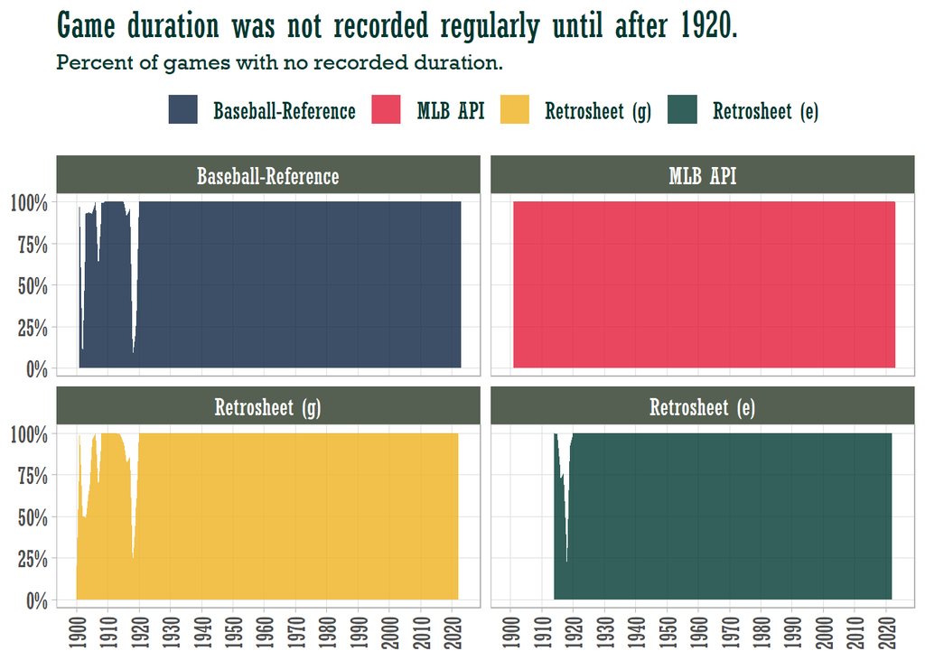

**Fig. 1a. Coverage**. Baseball Reference and MLB API cover 1901-present; Retrosheet (g) covers 1900-2022; and Retrosheet (e) covers 1914-2022. Note Baseball-Reference is Cleveland games only.

### 1b. Trend

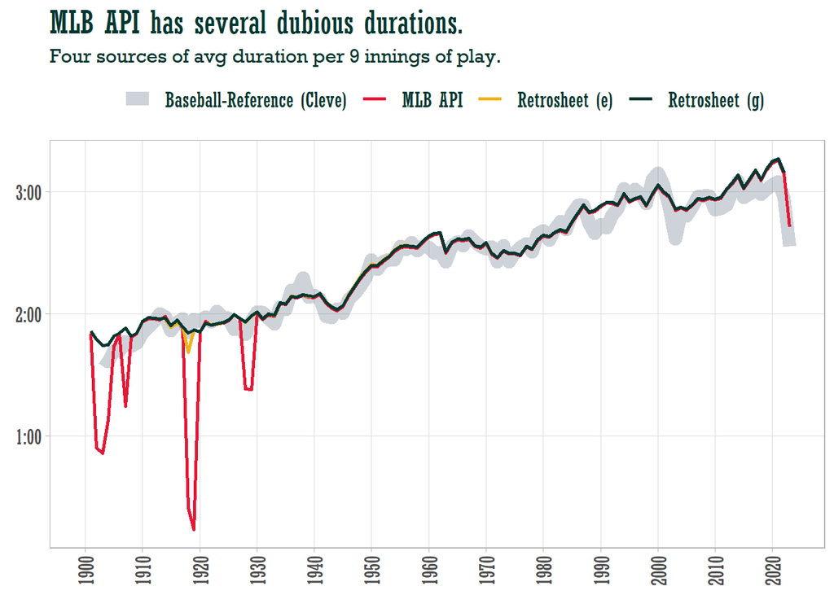

**Fig. 1b. Trend**. MLB API data has several problematic data points prior to 1930.

### 1c. Outliers

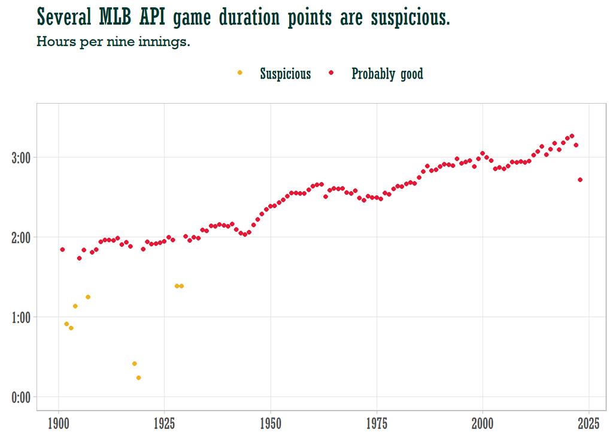

**Fig. 1c. MLB API’s Outliers**. A closer inspection identifies eight outliers.

### 1d. MICE

```r
# Remove everything related to pitch counts prior to 1999.
x <- mlb_season_ts_0 %>%
  mutate(across(P_9I:P_pitcher, ~if_else(season < 1999, NA_real_, .)))

# Remove bad values from time columns
y <- x %>%
  mutate(across(hrs_9I:mins_PA, ~if_else(season %in% dubious_seasons, NA, .)))

# Use MICE to impute values in the time cols
z <- y %>%
  select(hrs_9I, mins_PA, PA_9I, pitchers_9I, PA_pitcher, season) %>%
  mice::mice(print = FALSE, seed = 123) %>%
  complete()

mlb_season_ts_1 <- mlb_season_ts_0
mlb_season_ts_1$hrs_9I <- z$hrs_9I
mlb_season_ts_1$mins_PA <- z$mins_PA
```

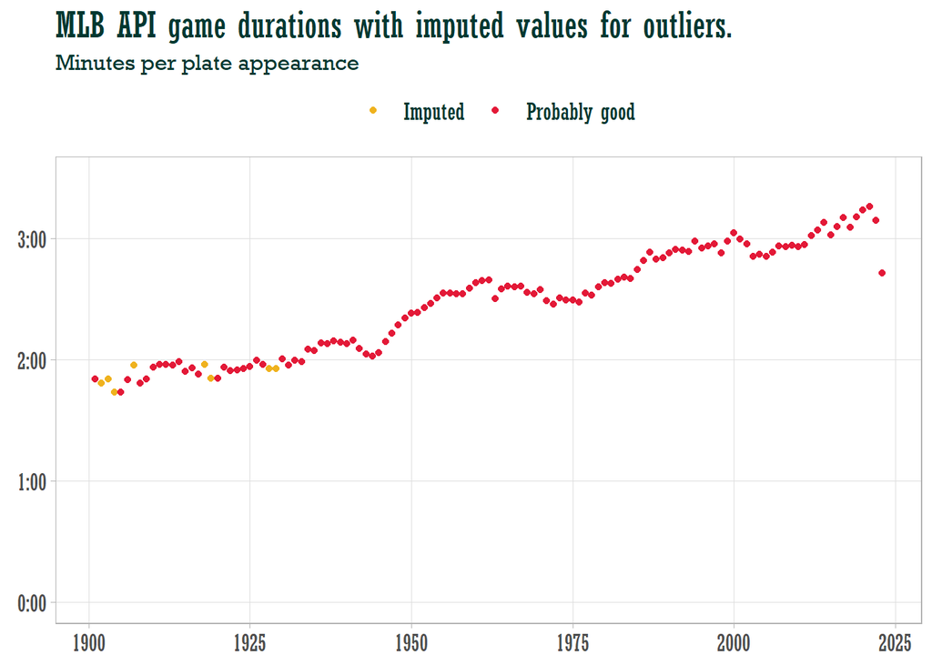

**Fig. 1d. MLB API with Imputations**. Using MICE to impute values produces realistic values.

### 1e. New Trend

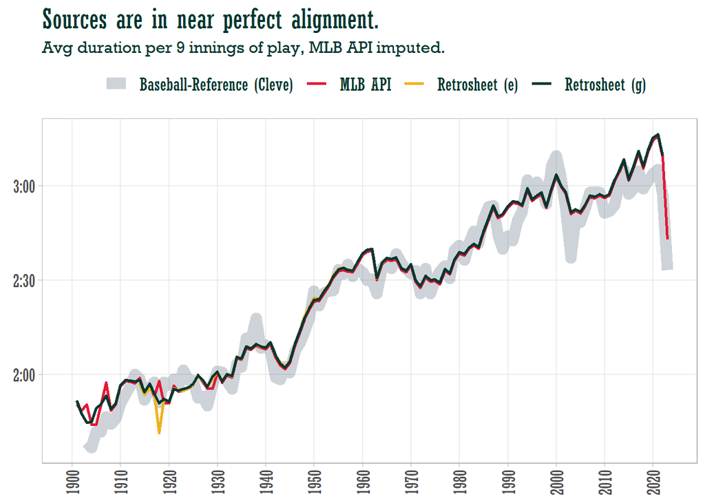

**Fig. 1e. New Trend**. The imputed data set now fits nicely with the others.

## Plate Appearances

My Baseball-Reference data under-counts plate appearances (PAs). The [MLB definition of PA](https://www.mlb.com/glossary/standard-stats/plate-appearance) is runs + outs + LOB. I defined PA as AB + sacs + BBs because I didn’t have LOB. Fig. 2a shows the trend of PA per nine-innings. MLB API is unrealistic prior to 1910. It is slightly lower than the two Retrosheet sources for the other years. Retrosheet looks like the more reliable source, but the trough between 1901 and 1920 is strange. Why did PA per 9 fall and rise like that? I will impute values for MLB API for 1901-1911 using Retrosheet (g) (Fig. 2b), but it seems like only 1920+ data is trustworthy.

What does Fig. 2b tell us? PA has a long gradual decline from 1935-1968 totaling nearly six less batters. If each batter takes around 2.5 minutes, that might reduce game times by 15 minutes. There is a partial recovery of five batters by 2000, then another decline. Changes in PA are an unlikely factor game duration.

### 2a. Trend

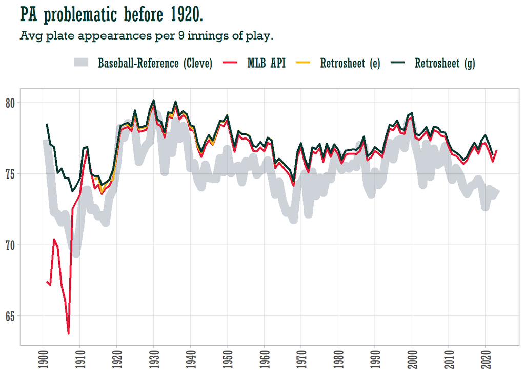

**Fig. 2a. Trend**. MLB API plate appearances per nine-innings diverges from other sources prior to 1910, but all values seem strange prior to 1920. Note Baseball-Reference is Cleveland games only, and uses rough approximation of PA and innings.

### 2b. New Trend

```r
mlb_season_ts_2 <- mlb_season_ts_1 %>%
  left_join(retro_season_g_ts %>% select(season, retro_PA_9I = PA_9I),
             by = join_by(season)) %>%
  mutate(PA_9I = if_else(season %in% 1901:1911, retro_PA_9I, PA_9I)) %>%
  select(-retro_PA_9I)
```

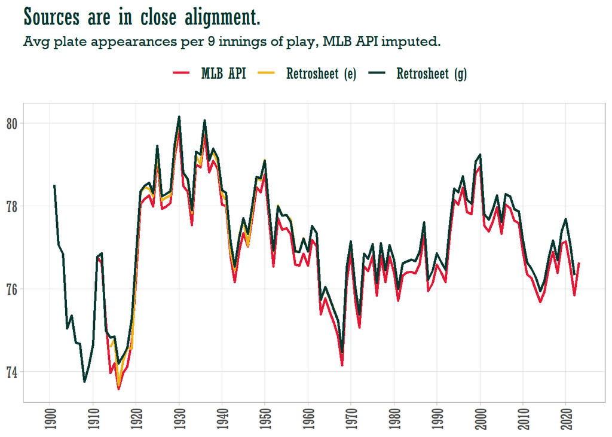

**Fig. 2b. Trend after Imputation**. MLB API data imputed for 1901-1911. Baseball-Reference not shown.

## Pitches

There is no recorded pitch counts until 1950 and until 1988 the values are less than half of what seems reasonable (Fig. 3a). The 1988-1998 values are still low and variable. Only 1999-present are consistent. I will null out all pitch counts prior to 1999. The pared down data set shows a small upward trend of about 10 additional pitches per nine innings since 1999 (Fig. 3b). The MLB-API data is lower by about 8 pitches per nine-innings. The lower pitch counts for MLB API along with the lower PAs make me suspect MLB API does not account for games when the home team does not bat in the bottom of the inning.

### 3a. Trend

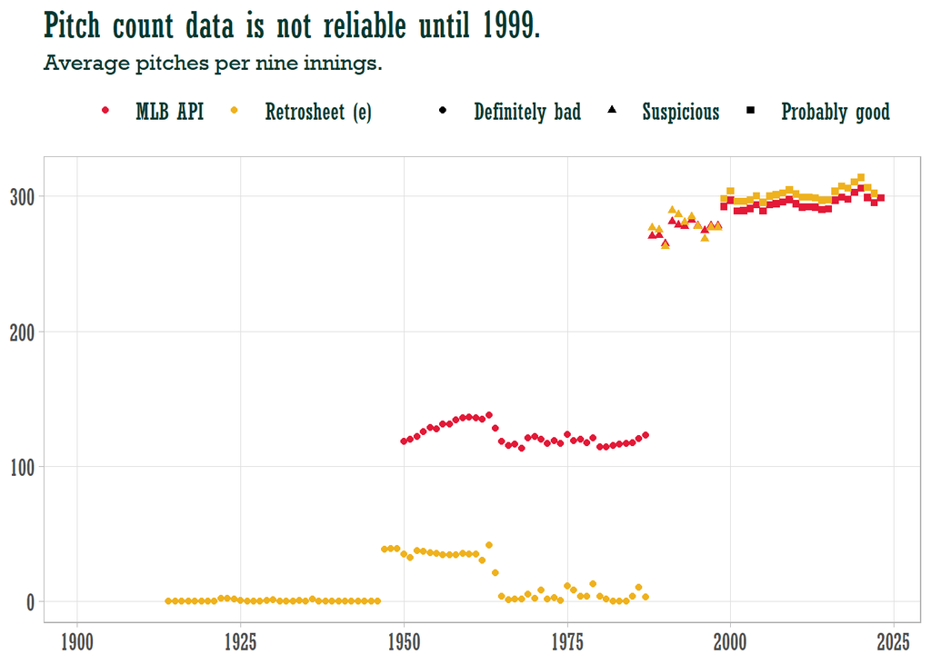

**Fig. 3a. Trend**. Pitch count per nine-innings. Shapes indicate plausibility.

### 3b. New Trend

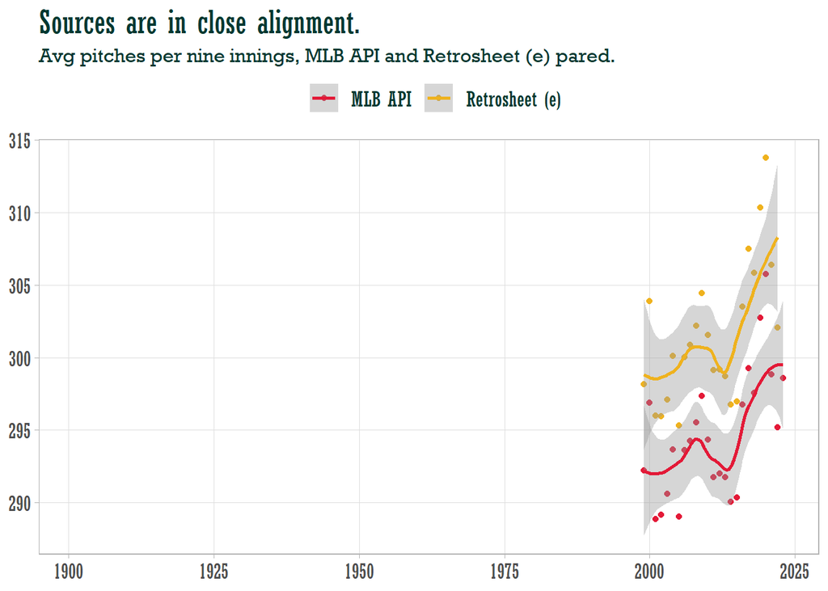

**Fig. 3b. New Trend**. Data sets after removing implausible data. MLB API is still lower than Retrosheet by about 8 pitches per game.

## Pitchers

### 4a. Total

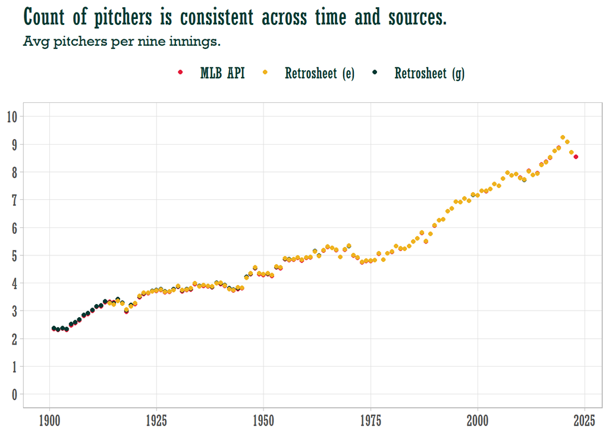

### 5b. Relievers

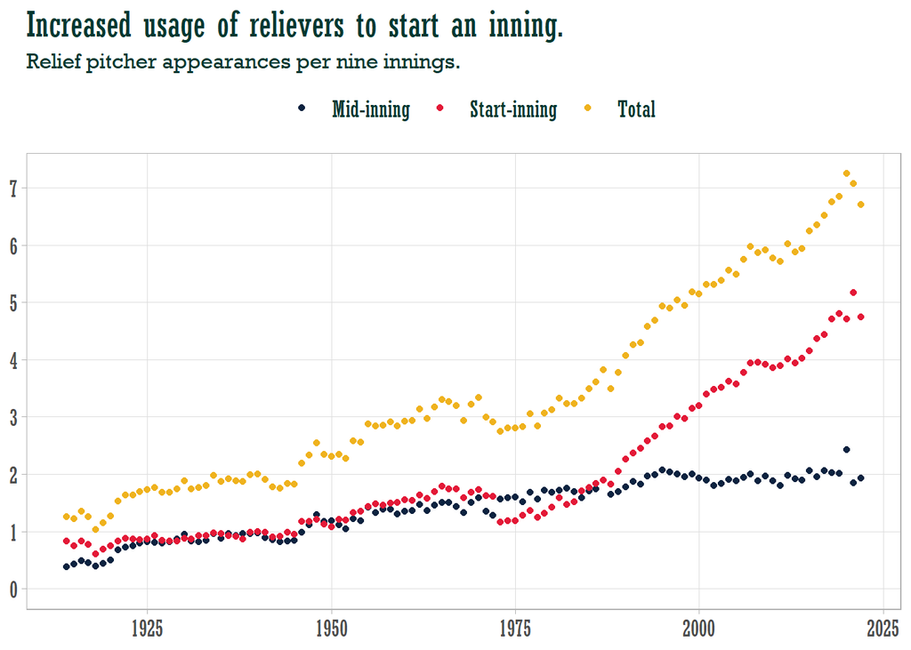

**Fig. 5b. Relievers**. Only Retrosheet (e) provides this level of detail.

## Stolen Bases

The stolen bases are less important because they shouldn’t affect game duration, but changes to its frequency are a bi-product of the 2023 rule changes related to base width and pick-off attempts. The caught-steeling data prior to 1926 is clearly not to be trusted, but what about the caught-stealing data from 1926 - 1950 (Fig. 6a)? I’m inclined to null out all of the caught-steeling data prior to 1951. There are also two outliers in 1914 and 1915. I don’t have an explanation for why they would pop up like that and it’s a big change from the prior trend. The 1914 outlier looks like it could be stolen base *attempts*. I will impute values for 1914 and 1915 (Fig. 6b).

### 6a. Trend

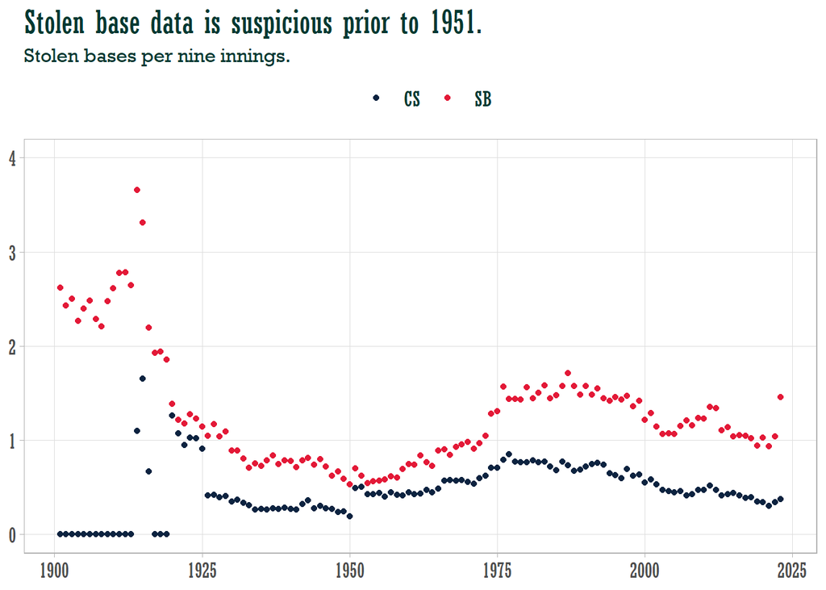

**Fig. 6a. Stolen bases per nine innings**.

### 6b. Redacted and Imputed

```r
# Remove everything related to pitch counts prior to 1999.
mlb_season_ts <- mlb_season_ts_3 %>%
  mutate(
    SB_9I = if_else(season %in% 1914:1915, NA_real_, SB_9I),
    CS_9I = if_else(season < 1951, NA_real_, CS_9I)
  )

# Use MICE to impute values in the time cols
x <- mlb_season_ts %>%
  select(season, SB_9I) %>%
  mice::mice(print = FALSE, seed = 123) %>%
  complete()

mlb_season_ts$SB_9I <- x$SB_9I
```

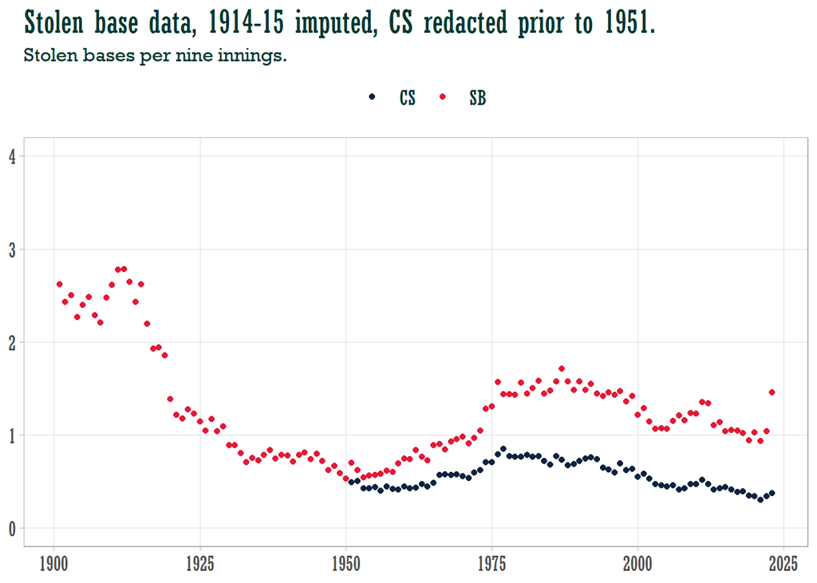

**Fig. 6b. Modified**. Stolen bases per nine innings, after removing caught-steeling prior to 1951 and imputing successes in 1914 and 1915.

# Save Data

Next I’ll dive into features, but there are no more modifications to the underlying data. Save it back to disk.

```r
saveRDS(bref_cle_season_ts, file.path("../data", "bref_cle_season_ts.rds"))
saveRDS(retro_season_e_ts, file.path("../data", "retro_season_e_ts.rds"))
saveRDS(retro_season_g_ts, file.path("../data", "retro_season_g_ts.rds"))
saveRDS(mlb_season_ts, file.path("../data", "mlb_season_ts.rds"))
```

# Feature Exploration

These subsections take a closer look at the time-related features in the data set.

## Game Duration

Games typically lasted around two hours up to 1945. Then over the course of ten seasons game times shot up to 2.5 hours. In the late 1970s games began another decade-long increase, hitting 2 hours 50 minutes in 1988. After 2011, game times began a third period of increase, reaching 3 hours 16 minutes in 2021. Several rule changes introduced in 2023 appear to have halted the advance. Average game times in 2023 through Jul 09 have been 2 hours 43 minutes, a reduction of 33 minutes.

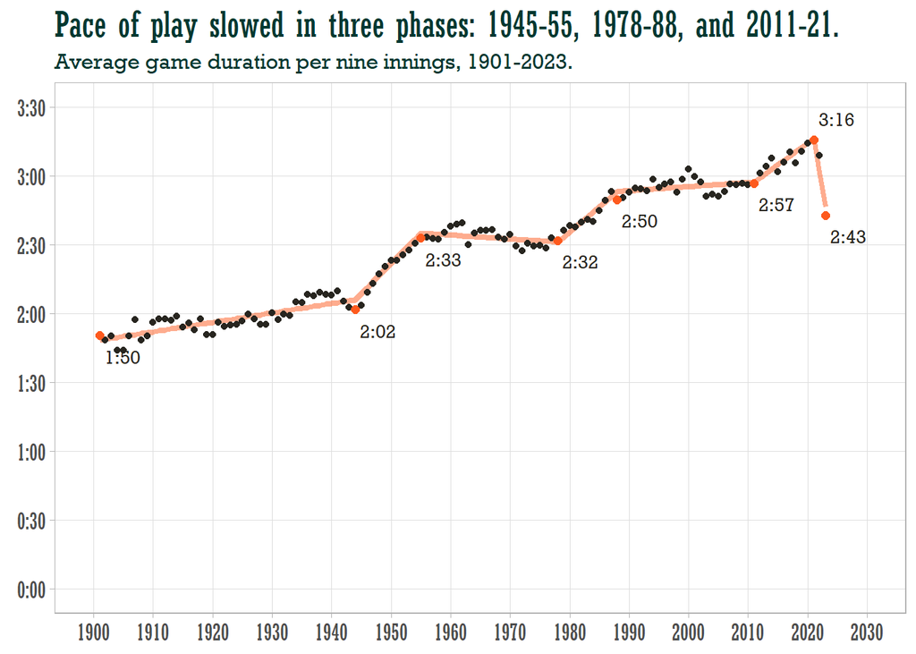

**Fig. 7. Average elapsed time per nine innings of play**. Source: MLB-API, 1901-Jul 09, 2023.

Doug Pappas chronicled the increased playing times in the Summer 1995 issue of Outside the Lines, the SABR Business of Baseball Committee newsletter. Pappas found a Sporting News article from 1962 blaming longer game times on full counts, pitching changes, and delays between pitches.[^2] I’ll consider these hypotheses and others below.

## Batting

Plate appearances (PA) per nine innings of play have changed little over time (Fig. 8a). Walks increased with game duration, at least through the 1940s, suggesting strategy was becoming increasingly important (Fig. 8b). Strikeouts in particular have increased with game times (Fig. 8c). Of the main offense metrics, strikeouts come closest to matching the trend in game duration. Strikeouts alone can explain about 94% of the variation in average game duration (Fig. 8d). Finally, hits (H) have fluctuated around 17 per nine innings since the 1940s (Fig. 8e).

### 8a. PA

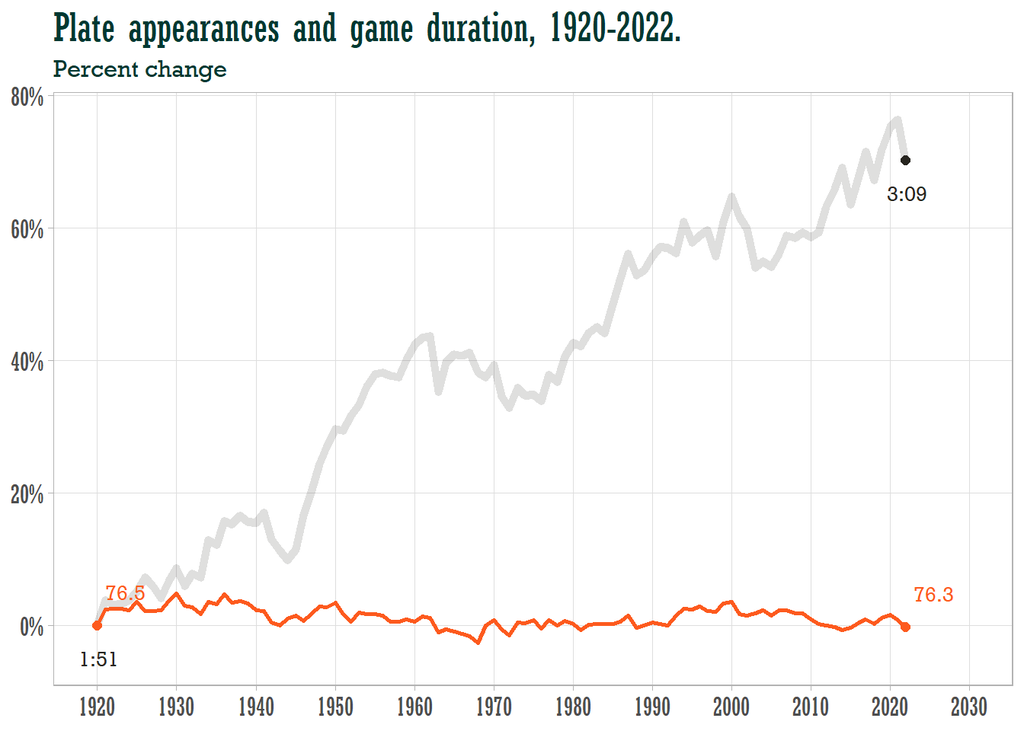

**Fig. 8a. Plate appearances (orange) and game duration (gray), per nine-innings**. Plate appearances are nearly unchanged.  
Source: Retrosheet Game.

### 8b. BB

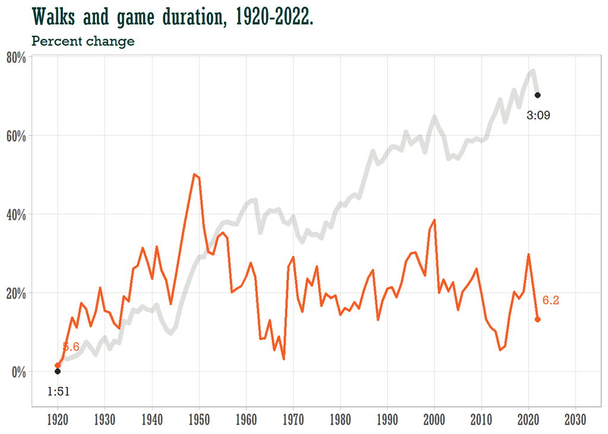

**Fig. 8b. Walks (orange) and game duration (gray), per nine-innings**. Walks increased with game duration until 1950.  
Source: Retrosheet Game.

### 8c. SO

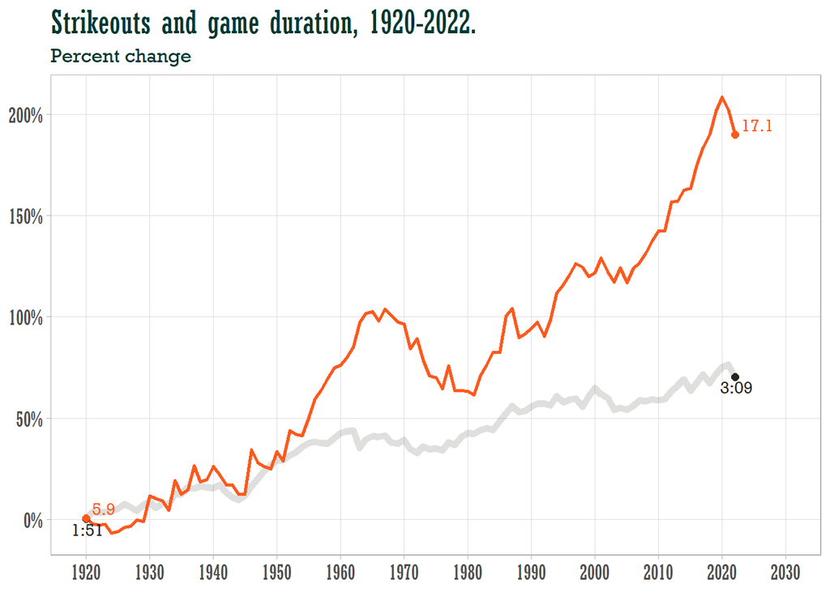

**Fig. 8c. Strikeouts (orange) and game duration (gray), per nine-innings**. Strikeouts climbed gradually after the dead-ball era, then more sharply after WWII. They declined from the mid-60’s to 1980, but have climbed since then, peaking at 18.2 in 2020.  
Source: Retrosheet Game.

### 8d. SO vs Hrs

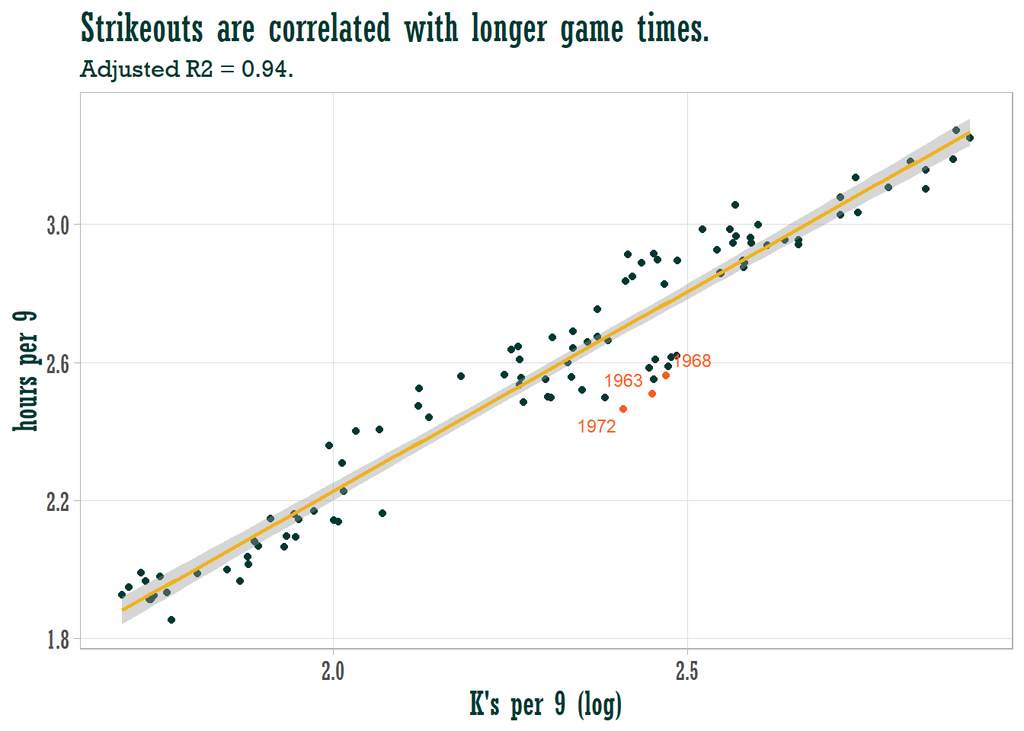

### 8e. H

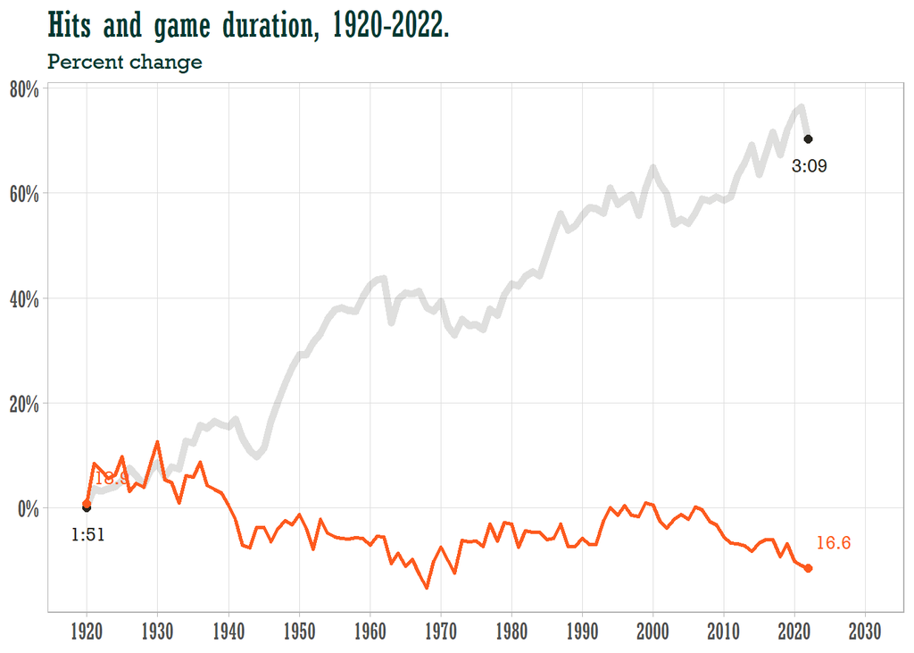

**Fig. 8e. Hits (orange) and game duration (gray), per nine-innings**. Hits decreased to about 17 by 1942 and have varied little since then.  
Source: Retrosheet Game.

## Pitching

The increase in pitcher appearances tracked game duration fairly well until they diverged around 1990 (Fig. 9a). The association is fairly linear, although there is evidence of autocorrelation (Fig. 9b). Fitting a model of game duration vs pitching appearances *and* strikeouts improves the explanatory power (R2 = 95%), but autocorrelation is still evident (Fig. 9c). I don’t know if it is the physical act of replacing a pitcher, or just the strategic activity implied by it (mound visits by coach and/or catcher, taking time between pitches, etc.). Fig. 9d focuses on the physical act by showing just the mid-inning pitching changes. Expressed as a percentage change, mid-inning relievers is choppy. The R2 on a model with just this variable is 93%. Fig. 9e shows the relationship with pitch counts, but the data set is limited, and the trend is flat.

### 9a. Pitchers

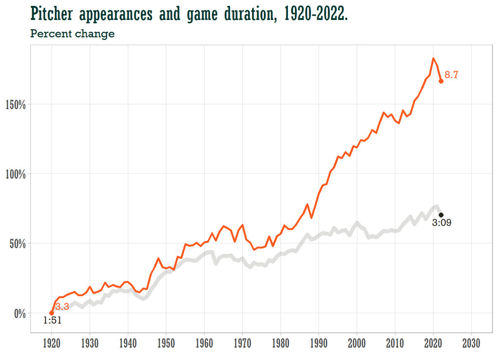

**Fig. 9a. Pitcher appearances (orange) and game duration (gray), per nine-innings**. The trends diverge around 1990.  
Source: Retrosheet Game.

### 9b. Pitches vs Hrs

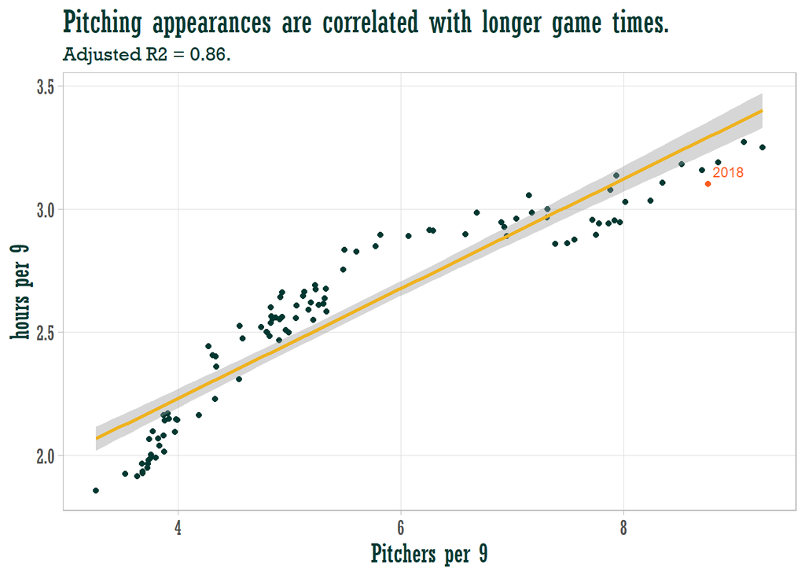

### 9c. Pitchers + K

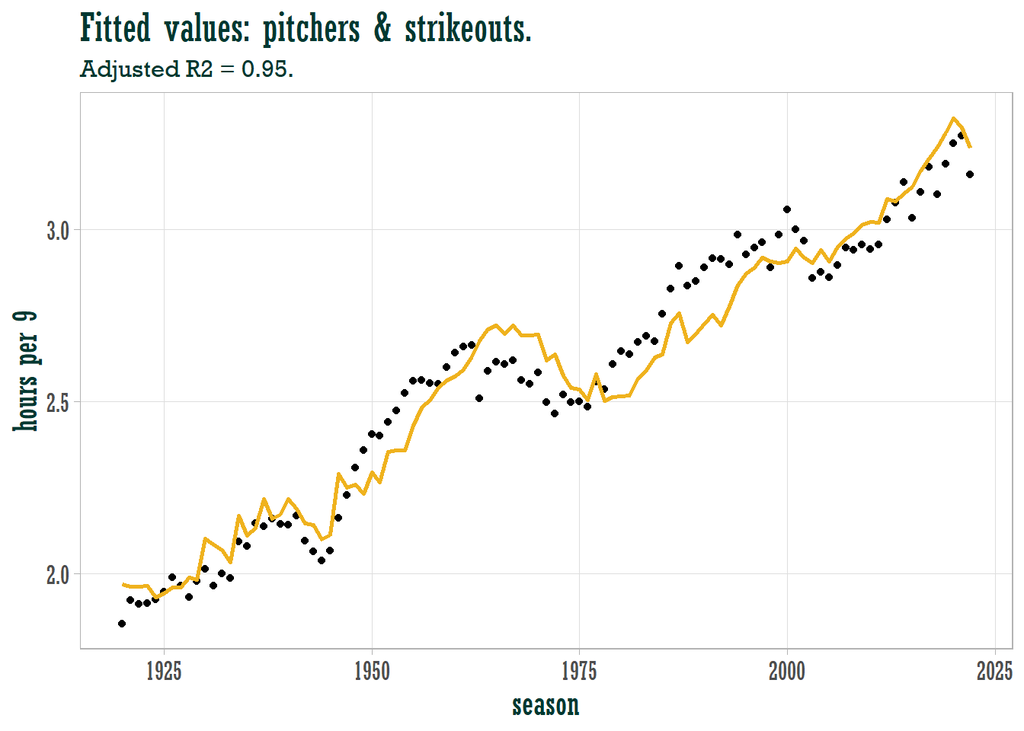

**Fig. 9c. Fitted values of model of hrs-per-9 vs log of strikeouts plus pitcher appearances.** Model still shows signs of autocorrelation. R-squared is 0.95.  
Source: Retrosheet Event.

### 9d. Mid-inning

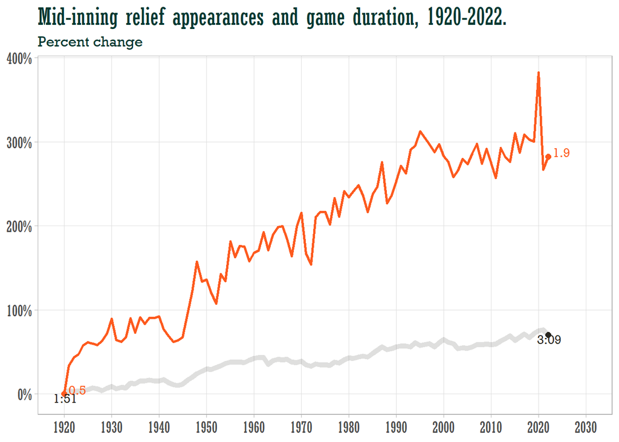

**Fig. 9d. Mid-inning relief appearances (orange) and game duration (gray), per nine-innings**.  
Source: Retrosheet Event.

### 9e. Pitches

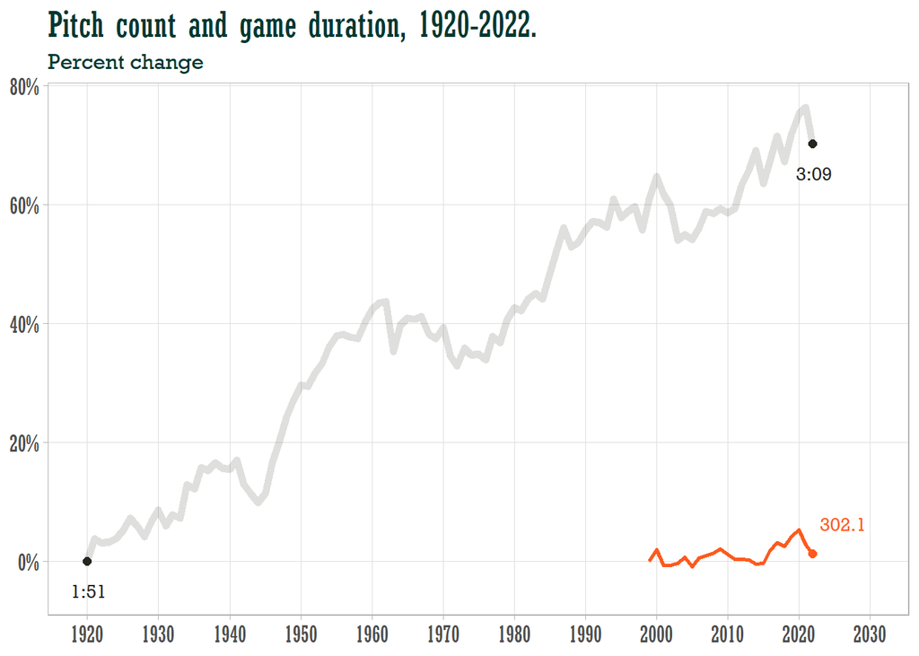

**Fig. 9e. Pitch counts (orange) and game duration (gray), per nine-innings**.  
Source: Retrosheet Event.

# Appendix A: Correlation Matrix

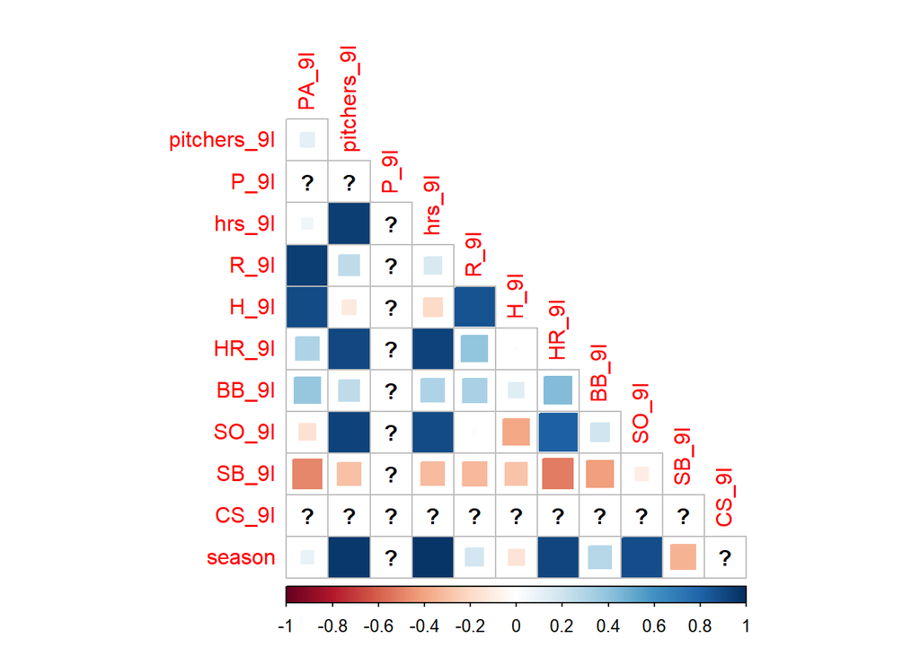

# Appendix B: Benchmark Forecasts

- The **average method** projects the historical average, $\hat{y}_{T+h|T} = \bar{y}.$
- The **naive method** projects the last observation, $\hat{y}_{T+h|T} = y_T.$
- The **seasonal naive method** projects the last seasonal observation, $\hat{y}_{T+h|T} = y_{T+h-m(k+1)}$.

The methods can include drift, a straight line from the first and last observation, $\hat{y}_{T+h|T} = y_T + h\left(\frac{y_T - y_1}{T-1}\right).$

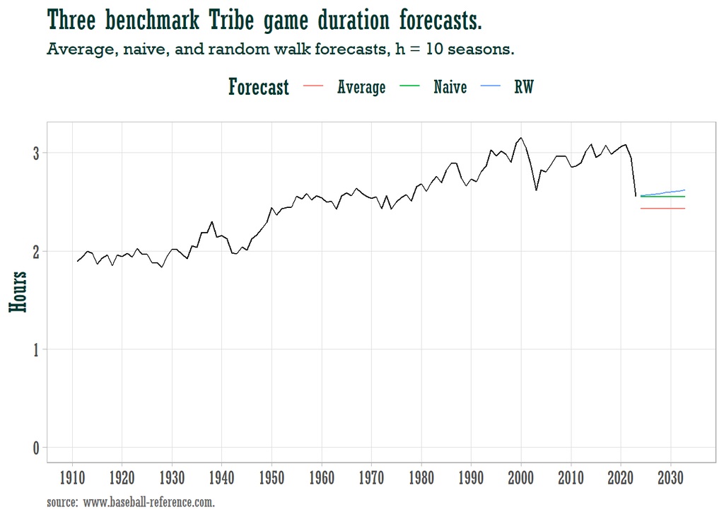

# Appendix C: Stolen Bases

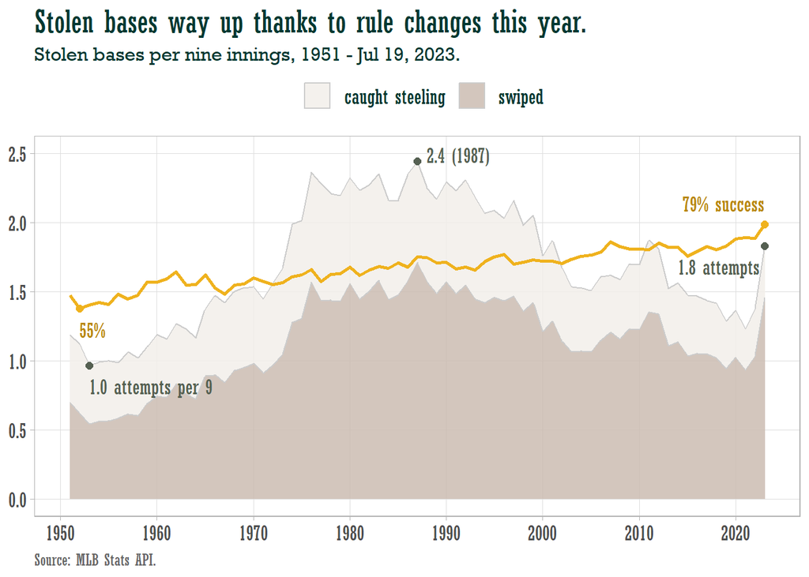

**Fig. 10. Stolen base attempts and success rate**. Attempts and success rate are up in 2023, but attempts are still well below modern era max in 1987.  
**Source**: MLB Stats API.

# Appendix D: Attendance

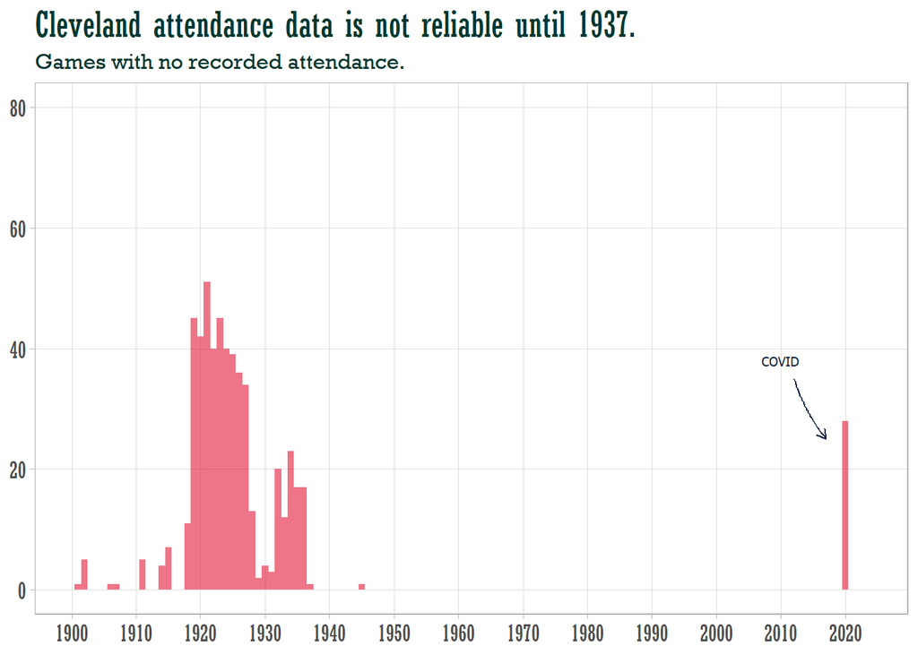

**Fig. 11**. Cleveland home games with no recorded attendance. Attendance at double-headers is only recorded for one game, so missing attendance related to double-headers is filtered out of this figure.  
Source: www.baseball-reference.com.

Attendance is constrained by the park capacity. Attendance might have been higher, at least in the 1990s when Cleveland sold out 455 straight games from 6/12/1995 through 4/2/2001. Here is a brief look at capacity:

- [League Park](https://en.wikipedia.org/wiki/League_Park) was built in 1891 and seated 9,000. The Spiders played their until folding after the 1899 season. The Indians (originally the Blues) started in 1901. In 1910 the park was rebuilt with concrete and steel with 18,000 seats.
- Municipal Stadium opened in 1932. The Indians played there from July 1932 through 1933, but returned to League Park in 1934 because attendance didn’t justify such a large facility. Beginning in 1937, the Indians played weekend and holiday games at Municipal stadium and gradually added more dates. Beginning in 1947 all games were played there.
- [Progressive Field](https://en.wikipedia.org/wiki/Progressive_Field) (named Jacobs Field from 1994-2007) opened in 1994 with a capacity of 42,865. Modifications increased capacity to 45,199 in 2009. Other modifications in 2011 reduced capacity to 43,441, then 36,856 in 2015, and 34,830 in 2021.

Attendance is generally correlated with winning, but something seems wrong with the two World Series years, 1948 and 1954. Average attendance in 1947, the first full season at Municipal Stadium, was 25,300. The Tribe finished 80-74 that year. The next season the Tribe went 97-58 and went on to win the World Series. Average attendance swelled to 40,300. Despite finishing 89-65 in 1949, attendance fell to 36,300, then to 26,700 in 1950. It continued to fall each season, reaching a low of 16,800 in 1953, despite 90+ wins each year. The 1954 season, with the gaudy 111-43 record only lifted attendance to 20,000 per game, attendance resumed its decline the following season. It briefly rebounded to 23,800 in 1959, but would not exceed 20,000 again until 1993.

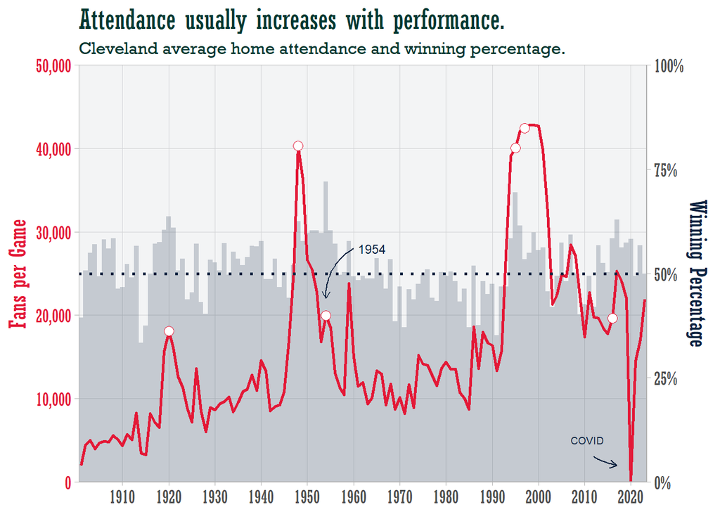

**Fig. 12**. Cleveland average home attendance and winning percentage. Attendance is generally accompanies improved play. World Series appearances years are highlighted. 1948 and 1954 stand out. 1948 is incredibly high relative to other winning seasons, and 1954 is low considering the dominant performance. 2023 home attendance YTD averages 21,888.  
Source: www.baseball-reference.com.

As an aside, check out 1917 and 1918. Game attendance does not seem unusual those two years despite WWI and the influenza pandemic. The US entered WWI in Apr ’17 and the war ended after the season concluded in ’18. The 1918 influenza pandemic started in the spring, but seems to have really taken off around October. Baseball survived the war as an acceptable diversion from civic duty, and in fact patriotic elements were integrated into the games.

For perspective, here is the Major League average with Cleveland attendance in the backdrop. MLB attendance trended upward until about 2007. The drop in 1995 followed the 1994-5 player strike. It seems possible all of MLB received a post-WWII attendance boost that corrected and returned to trend by the early 1950s.

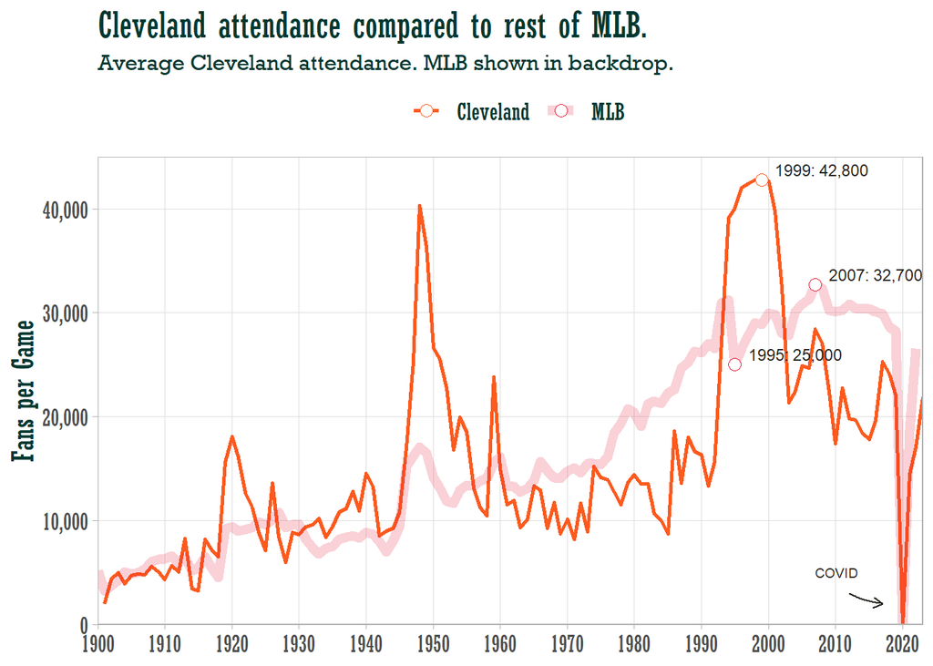

**Fig. 13**. Cleveland attendance peaked in 1999 and was 17,051 in 2022. 2023 through Jul 09 is 21,888. Major League Baseball attendance peaked in 2007. 2022 attendance averaged 26,577.  
Source: MLB API, Retrosheet.

# Appendix E: Other Clevaland Trends

## Doubleheaders

Prior to 1942, a few doubleheaders would be scheduled each season. There doesn’t appear to be a pattern: it might be on a Tuesday, for instance. Sunday doubleheaders became common in 1942, either scheduled or as make-ups. In 1943, most Sundays were scheduled doubleheaders and over 50% of baseball games overall were part of a doubleheader. Scheduled doubleheaders, esp. Sundays, were common through 1978. After that, only two or three might be scheduled.

Doubleheaders have become less common while game times have increased. Is there a negative correlation, perhaps a compensating effect? The answer is no, doubleheaders are irrelevant. The average doubleheader game is shorter by only 2 minutes.

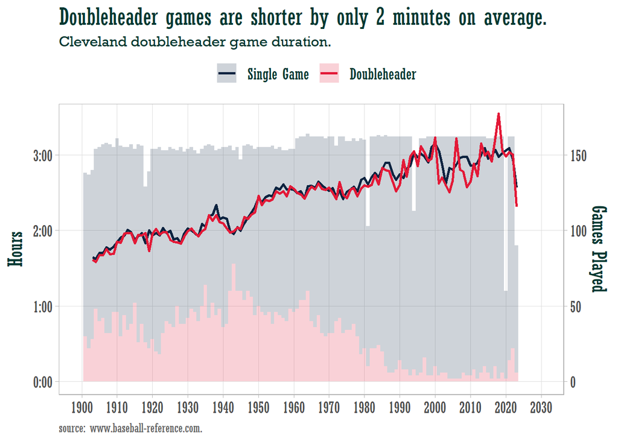

## Night Games

Until the late 1930s, all games were played in the afternoon. By the mid 1970s day games were primarily on weekends. While there might be a different dynamic to paying in the afternoon (*it’s hot - let’s get out of here!*), the data doesn’t bear that out. The advent of night games is not associated with longer games.

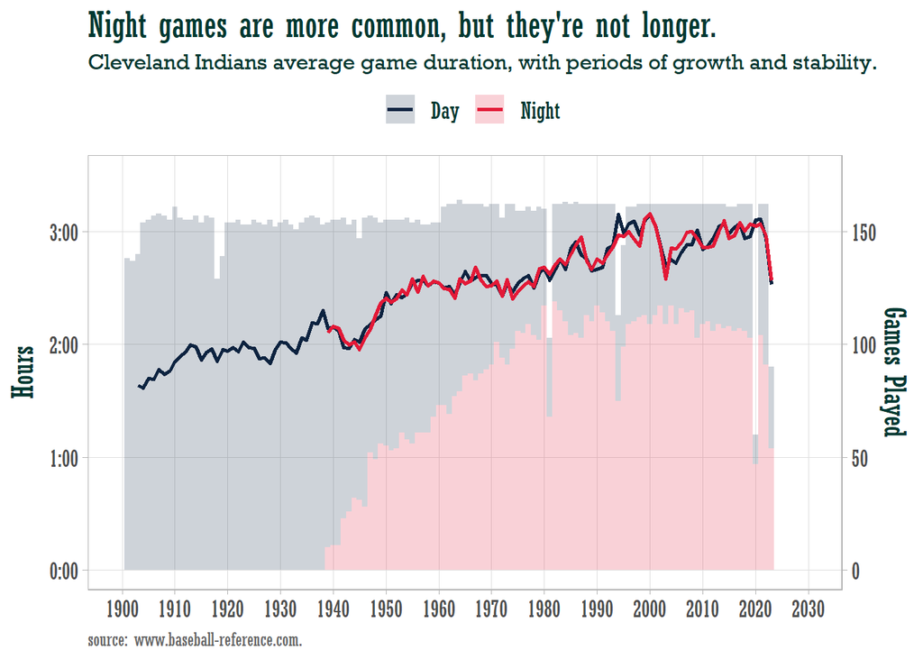

# Appendix F: Other Notes

According to [this Baseball Reference article on Pace of Play](https://www.baseball-reference.com/bullpen/Pace_of_play), Bill James identified mid-inning pitching substitutions as a break in the momentum of the game. James might appears to have been more concerned with the entertainment quality rather than pace. It also lists measures proposed to hasten pace, many of which are now in place: automatic intentional walks, regulating stepping out of batters box, pitch clock, shorter time between innings, limited mound visits, the three-batter rule, mound visit clock, and pitching change clock. The article references David Smith’s 2018 article (see below) attributing increased times to deeper counts and strikeouts leading to higher pitch counts. The pitch clock, introduced in the minors in 2022 reduced average game time by 25 minutes.

David W. Smith: “Why Do Games Take So Long?”, Baseball Research Journal, SABR, Vol. 47, Nr. 2 (Fall 2018), pp. 64-69. [html](https://sabr.org/journal/article/why-do-games-take-so-long/).]. David Smith (2018) concluded a rising pitch count is the predominant driver of game time. Smith relied on [Retrosheet](https://www.retrosheet.org/) for most of his analysis, but used other data for pitch counts.[^3].

David W. Smith: “Time Between Pitches: Cause of Long Games?”, Baseball Research Journal, SABR, Vol. 48 Nr. 2 (Fall 2019), pp. 24-28. [html](https://sabr.org/journal/article/time-between-pitches-cause-of-long-games/)

https://www.nyseconomicsassociation.org/wp-content/uploads/2022/06/nyer-sports-2020.pdf#page=24 https://sabr.org/journal/article/why-do-games-take-so-long/ https://github.com/BillPetti/baseballr/blob/master/R/retrosheet_data.R https://retrosheet.org/Research/SmithD/Relief%20Pitchers%20from%20Exile%20to%20Specialist.pdf https://fivethirtyeight.com/features/relievers-have-broken-baseball-we-have-a-plan-to-fix-it/ https://www.pitcherlist.com/retrosheet-play-by-play-data-at-your-fingertips/ https://techgraphs.fangraphs.com/tag/retrosheet/

[^1]: More on how to use MICE in [my blog](https://mpfoley73.netlify.app/post/2022-07-26-imputing-values-with-mice/)
[^2]: Doug Pappas. Originally published in the Summer 1995 issue of Outside the Lines, the SABR Business of Baseball Committee newsletter. [html](http://roadsidephotos.sabr.org/baseball/95gamelength.htm).
[^3]: I used Retrosheet data in [my study on baseball player longevity](https://mpfoley73.github.io/baseball-survival/1_full_analysis.html)